# Insights for HIV Interventions among Millennials

## Background

While the number of HIV cases in the US has been dropping, several localized HIV epidemics have occurred among young adults in the rural-adjacent areas of Scott County, Indiana, Cabell County, West Virginia, and Hamilton County, Ohio.<sup>1-4</sup> The CDC has highlighted more than 200 counties across the country that are at risk for an HIV outbreak (Figure 1).<sup>5</sup> These HIV epidemics are associated with risky behaviors such as sharing injection equipment and unprotected sex among individuals who were unaware of their HIV status. Understanding the demographical, social economical and behavioral risk factors related to HIV testing and HIV risk behavior among millennials could provide important insights to identify target population for future interventions.

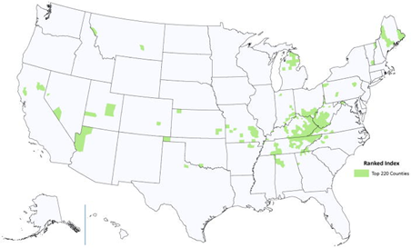

**Figure 1. Counties for which estimated vulnerability scores or their upper 90% confidence interval exceeded the 95th percentile. (CDC)**

As a lot of prevention and management of HIV are performed in primary care settings, we would expect having a primary care provider may reduce HIV risk. In real life, the number of primary care physicians in the US has been declining and is projected to continue declining, especially in rural areas.<sup>6</sup> This decline is cooccurring with a decrease in the number of young adults with a primary care physician.<sup>7</sup> Another characteristic that may contribute to the probability of performing HIV risk behaviors could be the urban/rural status. The recent localized outbreaks mentioned earlier are mostly in rural area, and the CDC map also shows that rural counties are particularly vulnerable to HIV (Figure 1). Harm reduction programs, such as syringe service programs have been proven to be effective at reducing HIV transmission and increase HIV testing, but not in rural areas, due to stigma against those harm reduction approaches.<sup>8</sup> At the same time, rural counties have less primary care providers that could provide preventive care, HIV testing, and important information.

We have talked about having a primary care provider and the urban/rural status as potential determinants of HIV testing and HIV risk behaviors. Other potential risk factors include demographics, such as age, gender, general health, marital status, income, healthcare coverage, and behavioral habits, including smoking, drinking, diet, and exercise.

The **research question** of this project is **What are the demographical, social economical and behavioral features related to HIV testing and risk behavior among millennials?** Understanding that could provide important insights to identify target population and potential strategies for future interventions.

To answer the research question, I used the behavioral risk factor surveillance system, or BRFSS. It is the nation’s premier system of health-related telephone surveys that collect state data about U.S. residents regarding their health-related risk behaviors, chronic health conditions, and use of preventive services. Established in 1984 with 15 states, BRFSS now collects data in all 50 states as well as the District of Columbia and three U.S. territories. It completes more than 400,000 adult interviews each year, making it the largest continuously conducted health survey system in the world. It is a powerful tool for targeting and building health promotion activities, and the data are publicly available.

## Data Source

- The Behavioral Risk Factor Surveillance System (BRFSS) 2019
- Downloaded from [https://www.cdc.gov/brfss/index.html](https://urldefense.com/v3/__https://www.cdc.gov/brfss/index.html__;!!KGKeukY!gZTZPCc5hGGOe4U5syrw--8wW0LFxA4Nj3ktmCQgGqQ537ZrZxoxhEo9S4LjtmUz$)

## Variables

### Primary outcome

1. **HIV risk behaviors (Y/N)**: I am going to read you a list. When I am done, please tell me if any of the situations apply to you. You do not need to tell me which one.

   *You have injected any drug other than those prescribed for you in the past year.*

   *You have been treated for a sexually transmitted disease or STD in the past year.*

   *You have given or received money or drugs in exchange for sex in the past year.*
1. **HIV testing (Y/N)**: Have you ever been tested for HIV? Do not count tests you may have had as part of a blood donation. Include testing fluid from your mouth.

### Independent variables

#### Health behaviors

```
- Drinking: total number of alcoholic beverages consumed per week
- Smoking: Four-level smoker status (Everyday smoker, Someday smoker, Former smoker, Non-smoker)
- Diet (fruit): Total fruits consumed per day
- Diet (Vegetable): Total vegetables consumed per day
- Physical exercise: Adults who reported doing physical activity or exercise during the past 30 days other than their regular job
- Physical exercise: Minutes of total Physical Activity per week
- Physical exercise: Meet the Aerobic and Strengthening standard or not (2-level)
```

#### Chronic conditions

```
- Asthma: Adults who have ever been told they have asthma
- Difficulty Concentrating or Remembering
- Diabetes: (Ever told) you had diabetes
- Heart attack: Ever Diagnosed with Heart Attack
- Stroke: Ever Diagnosed with a Stroke
```

#### Demographics:

```
- Age in 5-yr categories
- BMI: Four-categories of Body Mass Index (BMI)
- Sex
- Imputed race/ethnicity value
- Income categories
- Level of education completed
- Employment
- Marital status
- Do you own or rent your home?
- Are You A Veteran
- Urban/Rural Status
```

#### Healthcare access

```
- Do you have one person you think of as your personal doctor or health care provider?
- Could Not See Doctor Because of Cost (yes/no)
```

## Data Cleaning

1. Subset to millennials
2. Keep the variables we are interested in
3. Imputation for missing values in independent variables
4. Recode categorical variables
5. One hot encoding for the categorical variables with multiple levels

The data cleaning process was performed in R. The R code used is as follows.

```
# import the XPT file
library(Hmisc)
brfss <- sasxport.get("C:\\Files\\OSU\\Fall 2020\\BMI 8050\\Project\\Data\\LLCP2019XPT\\LLCP2019.xpt")
# save as csv
# write.csv(brfss,'C:\\Files\\OSU\\Fall 2020\\BMI 8050\\Project\\Data\\LLCP2019XPT\\brfss19.csv')

# check the variables
names(brfss)
# keep only millanials
brfss2 <- brfss[ which(brfss$x.age80 < 40), ]
rm(brfss)

# keep the variables needed
brf <- brfss2[ c(1, 8, 9, 38, 39, 46, 48, 56, 64, 66, 70, 71, 79, 112,
                 236, 238:242, 259, 272, 273, 281, 284:286, 291, 313, 321,
                 332, 333, 342)]

names(brf)
attach(brf)
table(persdoc2) #4
brf$persdoc <- ifelse(persdoc2 < 3, 1, 0)
table(brf$persdoc, persdoc2)
table(medcost) #5
brf$medcost2 <- ifelse(medcost < 2, 1, 0)
brf$medcost2[is.na(brf$medcost2)] <- 0
table(brf$medcost2, medcost)
table(brf$medcost2)
table(cvdinfr4) #6
brf$cvdinfr <- ifelse(cvdinfr4 < 2, 1, 0)
table(brf$cvdinfr, cvdinfr4)
table(brf$cvdinfr)
table(cvdstrk3) #7
brf$cvdstrk <- ifelse(cvdstrk3 < 2, 1, 0)
table(brf$cvdstrk, cvdstrk3)
table(brf$cvdstrk)
table(diabete4) #8
brf$diabete <- ifelse(diabete4 < 3, 1, 0)
table(brf$diabete, diabete4)
table(brf$diabete)
table(brf$marital)
brf$marital[is.na(brf$marital)] <- 5
table(brf$renthom1) #10
brf$renthom <- ifelse(renthom1 < 2, 1, 0)
brf$renthom[is.na(brf$renthom)] <- 0
table(brf$renthom, renthom1)
table(brf$renthom)
table(veteran3) #11
brf$veteran <- ifelse(veteran3 < 2, 1, 0)
brf$veteran[is.na(brf$veteran)] <- 0
table(brf$veteran, veteran3)
table(brf$veteran)
table(employ1)
brf$employ1[is.na(brf$employ1)] <- 1
table(decide) #13
brf$decide2 <- ifelse(decide < 2, 1, 0)
brf$decide2[is.na(brf$decide2)] <- 0
table(brf$decide2, decide)
table(brf$decide2)
table(brf$x.urbstat) #15
brf$x.urbstat[is.na(brf$x.urbstat)] <- 1
brf$x.urbstat2 <- ifelse(brf$x.urbstat < 2, 1, 0)
table(brf$x.urbstat2, x.urbstat)
table(brf$x.urbstat2)
table(brf$x.ltasth1)
brf$x.ltasth1[brf$x.ltasth1==9] <- 1
brf$x.ltasth1[is.na(brf$x.ltasth1)] <- 1
brf$x.ltasth1[brf$x.ltasth1 == 2] <- 0
table(brf$x.ageg5yr)
brf$x.ageg5yr[brf$x.ageg5yr == 14] <- 1
table(brf$x.bmi5cat)
brf$x.bmi5cat[is.na(brf$x.bmi5cat)] <- 2
table(brf$x.educag)
brf$x.educag[brf$x.educag == 9] <- 4
table(brf$x.incomg)
brf$x.incomg[brf$x.incomg == 9] <- 5
table(brf$x.smoker3)
brf$x.smoker3[brf$x.smoker3 == 9] <- 4
table(brf$x.drnkwk1)
brf$x.drnkwk1[brf$x.drnkwk1 == 99900] <- 0
table(brf$pa2vigm.)
brf$pa2vigm.[is.na(brf$pa2vigm.)] <- 0
table(brf$x.pastae2)
brf$x.pastae2[brf$x.pastae2 == 9] <- 2
brf$x.pastae2[brf$x.pastae2 == 2] <- 0
table(brf$x.frutsu1)
brf$x.frutsu1[is.na(brf$x.frutsu1)] <- 100
table(brf$x.vegesu1)
brf$x.vegesu1[is.na(brf$x.vegesu1)] <- 200
brf$x.sex[brf$x.sex == 2] <- 0

# save as csv
write.csv(brf,'C:\\Files\\OSU\\Fall 2020\\BMI 8050\\Project\\Data\\LLCP2019XPT\\brf.csv')
names(brf)
brf2 <- brf[ -c(3:8, 10, 11, 13, 15:19)]
detach(brf)
summary(brf2)
# categorical: x.state, marital, employ1, x.imprace, x.ageg5yr, x.bmi5cat, x.educag, x.incomg, x.smoker3,
# recode to dummy variables
# install.packages("dummies")
library(dummies)
brf3 <- dummy.data.frame(brf2, names = c("x.state", "marital", "employ1", "x.imprace", "x.ageg5yr", "x.bmi5cat", "x.educag",
                                         "x.incomg", "x.smoker3"))
summary(brf3)

# for hiv risk behavior
risk <- brf3[(brf3$hivrisk5 == 1 | brf3$hivrisk5 == 2),]
risk$hivrisk5[risk$hivrisk5 == 2] <- 0
table(risk$hivrisk5)
names(risk)
risk2 <- risk[complete.cases(risk[ ,70]),]
names(risk2)

# for those without one-hoc encoding
risk3 <- brf2[(brf2$hivrisk5 == 1 | brf2$hivrisk5 == 2),]
risk3$hivrisk5[risk3$hivrisk5 == 2] <- 0
table(risk3$hivrisk5)
names(risk3)
risk4 <- risk3[complete.cases(risk3[ ,5]),]
names(risk4)
risk5 <- risk4[ -c(2, 19)]


# save as csv
write.csv(risk2,'C:\\Files\\OSU\\Fall 2020\\BMI 8050\\Project\\Data\\LLCP2019XPT\\riskfull.csv')
write.csv(risk5,'C:\\Files\\OSU\\Fall 2020\\BMI 8050\\Project\\Data\\LLCP2019XPT\\riskfullc.csv')


# for hiv testing
table(brf3$x.aidtst4)
test <- brf3[(brf3$x.aidtst4 == 1 | brf3$x.aidtst4 == 2),]
test$x.aidtst4[test$x.aidtst4 == 2] <- 0
table(test$x.aidtst4)
names(test)
test2 <- test[complete.cases(test[ ,105]),]
summary(test2)

# for those without one-hoc encoding
table(brf2$x.aidtst4)
test3 <- brf2[(brf2$x.aidtst4 == 1 | brf2$x.aidtst4 == 2),]
test3$x.aidtst4[test3$x.aidtst4 == 2] <- 0
table(test3$x.aidtst4)
names(test3)
test4 <- test3[complete.cases(test3[ ,19]),]
summary(test4)
test5 <- test4[ -c(2, 5)]

# save as csv
write.csv(test2,'C:\\Files\\OSU\\Fall 2020\\BMI 8050\\Project\\Data\\LLCP2019XPT\\testfull.csv')
write.csv(test5,'C:\\Files\\OSU\\Fall 2020\\BMI 8050\\Project\\Data\\LLCP2019XPT\\testfullc.csv')
```

## Statistical Analysis

Based on the nature of the data and research question, deep neural network was performed. Random forest was also utilized to compare the results as a traditional machine learning technique.

- For model tuning, a lot of other models were fit. The fllowing ones are the most representative during the tuning process and the ones with best performance.

### Set Up

```python
import pandas as pd
import tensorflow as tf
from tensorflow import keras
from tensorflow import feature_column
from tensorflow.keras import layers

import numpy as np
import matplotlib.pyplot as plt

import os
import tempfile

import matplotlib as mpl
import matplotlib.pyplot as plt

import sklearn
from sklearn.metrics import confusion_matrix
from sklearn.metrics import precision_recall_curve
from sklearn.metrics import f1_score
from sklearn.model_selection import train_test_split
from sklearn.preprocessing import StandardScaler
```

```python
mpl.rcParams['figure.figsize'] = (12, 10)
colors = plt.rcParams['axes.prop_cycle'].by_key()['color']
```

## Outcome 1: HIV risk behavior

### Importing Data

```python
df = pd.read_csv('riskfull.csv')
print(df.head())
```

```
   x.state1  x.state2  x.state4  x.state5  x.state6  x.state8  x.state9  \
0         1         0         0         0         0         0         0
1         1         0         0         0         0         0         0
2         1         0         0         0         0         0         0
3         1         0         0         0         0         0         0
4         1         0         0         0         0         0         0

   x.state10  x.state11  x.state12  ...  x.vegesu1  persdoc  medcost2  \
0          0          0          0  ...        170        0         0
1          0          0          0  ...        157        0         0
2          0          0          0  ...        200        1         0
3          0          0          0  ...        139        1         0
4          0          0          0  ...        193        1         0

   cvdinfr  cvdstrk  diabete  renthom  veteran  decide2  x.urbstat2
0        0        0        0        1        0        0           1
1        0        0        0        1        0        0           1
2        0        0        0        1        0        0           1
3        0        0        0        1        0        0           1
4        0        0        0        1        0        0           0

[5 rows x 112 columns]
```

```python
# Examine the imbalance
neg, pos = np.bincount(df['hivrisk5'])
total = neg + pos
print('Examples:\n    Total: {}\n    Positive: {} ({:.2f}% of total)\n'.format(
    total, pos, 100 * pos / total))
```

```
Examples:
    Total: 81942
    Positive: 10165 (12.41% of total)
```

Imbalanced data, class weights are needed to adjust for that. Meanwhile, for the model evaluation, a precision-recall curve should be used instead of a ROC curve.

```python
# Scaling by total/2 helps keep the loss to a similar magnitude.
# The sum of the weights of all examples stays the same.
weight_for_0 = (1 / neg)*(total)/2.0
weight_for_1 = (1 / pos)*(total)/2.0

class_weight = {0: weight_for_0, 1: weight_for_1}

print('Weight for class 0: {:.2f}'.format(weight_for_0))
print('Weight for class 1: {:.2f}'.format(weight_for_1))
```

```
Weight for class 0: 0.57
Weight for class 1: 4.03
```

```python
# Log transform the four continuous variables to reduce its range
eps = 0.001
df['logdrnk'] = np.log(df.pop('x.drnkwk1')+eps)
df['logfru'] = np.log(df.pop('x.frutsu1')+eps)
df['logveg'] = np.log(df.pop('x.vegesu1')+eps)
df['logpa'] = np.log(df.pop('pa2vigm.')+eps)
```

### Splitting Dataset into Train， Validation and Test Feature Matrix and Dependent Vector

```python
# 20% for testing and 80/20 for training and validation
train, test = train_test_split(df, test_size=0.2)
train, val = train_test_split(train, test_size=0.2)
print(len(train), 'train examples')
print(len(val), 'validation examples')
print(len(test), 'test examples')
```

```
52442 train examples
13111 validation examples
16389 test examples
```

```python
# Form np arrays of labels and features.
train_labels = np.array(train.pop('hivrisk5'))
bool_train_labels = train_labels != 0
val_labels = np.array(val.pop('hivrisk5'))
test_labels = np.array(test.pop('hivrisk5'))

train_features = np.array(train)
val_features = np.array(val)
test_features = np.array(test)
```

```python
print('Training labels shape:', train_labels.shape)
print('Validation labels shape:', val_labels.shape)
print('Test labels shape:', test_labels.shape)

print('Training features shape:', train_features.shape)
print('Validation features shape:', val_features.shape)
print('Test features shape:', test_features.shape)
```

```
Training labels shape: (52442,)
Validation labels shape: (13111,)
Test labels shape: (16389,)
Training features shape: (52442, 111)
Validation features shape: (13111, 111)
Test features shape: (16389, 111)
```

### Model Creation, Compilation, and Training

To alow change in learning rate as the number of training epochs increases, adavptive learning rate was used (through power scheduling).

For the HIV risk behavior outcome, due to the imbalance nature of the data, class weight was used as an adjustment.

```python
METRICS = [
      keras.metrics.TruePositives(name='tp'),
      keras.metrics.FalsePositives(name='fp'),
      keras.metrics.TrueNegatives(name='tn'),
      keras.metrics.FalseNegatives(name='fn'),
      keras.metrics.BinaryAccuracy(name='accuracy'),
      keras.metrics.Precision(name='precision'),
      keras.metrics.Recall(name='recall'),
      keras.metrics.AUC(name='auc'),
]

# Power scheduling
optimizer = keras.optimizers.SGD(lr=0.01, decay=1e-4)

def make_model(metrics=METRICS, optimizer=optimizer, output_bias=None):
  if output_bias is not None:
    output_bias = tf.keras.initializers.Constant(output_bias)
  model = keras.Sequential([
      keras.layers.Dense(128, activation='relu',
          input_shape=(train_features.shape[-1],)),
      keras.layers.Dropout(0.5),
      #keras.layers.Dense(32, activation='relu'),
      #keras.layers.Dropout(0.2),
      keras.layers.Dense(1, activation='sigmoid',
                         bias_initializer=output_bias),
  ])

  model.compile(
      optimizer=optimizer,
      loss=keras.losses.BinaryCrossentropy(),
      metrics=metrics)

  return model
```

Multiple batch sizes have been tested and 25 seems to work the best with the data (based on the history of Loss function graph and acuuracy).

```python
# a large number of Epochs is set here with early stopping
EPOCHS = 200
BATCH_SIZE = 25

early_stopping = tf.keras.callbacks.EarlyStopping(
    monitor='val_auc',
    verbose=1,
    patience=10,
    mode='max',
    restore_best_weights=True)
```

```python
model = make_model()
model.summary()
```

```
Model: "sequential_58"
_________________________________________________________________
Layer (type)                 Output Shape              Param #
=================================================================
dense_150 (Dense)            (None, 128)               14336
_________________________________________________________________
dropout_91 (Dropout)         (None, 128)               0
_________________________________________________________________
dense_151 (Dense)            (None, 1)                 129
=================================================================
Total params: 14,465
Trainable params: 14,465
Non-trainable params: 0
_________________________________________________________________
```

```python
model.predict(train_features[:10])
```

```
array([[0.21390606],
       [0.09557574],
       [0.6247932 ],
       [0.04970116],
       [0.21788475],
       [0.1356516 ],
       [0.06278118],
       [0.17332998],
       [0.23647094],
       [0.31101894]], dtype=float32)
```

```python
# set the initial weights
initial_weights = os.path.join(tempfile.mkdtemp(), 'initial_weights')
model.save_weights(initial_weights)
```

```python
model = make_model()
model.load_weights(initial_weights)
model.layers[-1].bias.assign([0.0])
zero_bias_history = model.fit(
    train_features,
    train_labels,
    batch_size=BATCH_SIZE,
    epochs=20,
    validation_data=(val_features, val_labels),
    verbose=0)
```

```python
model = make_model()
model.load_weights(initial_weights)
careful_bias_history = model.fit(
    train_features,
    train_labels,
    batch_size=BATCH_SIZE,
    epochs=20,
    validation_data=(val_features, val_labels),
    verbose=0)
```

```python
def plot_loss(history, label, n):
  # Use a log scale to show the wide range of values.
  plt.semilogy(history.epoch, history.history['loss'],
               color=colors[n], label='Train '+label)
  plt.semilogy(history.epoch, history.history['val_loss'],
          color=colors[n], label='Val '+label,
          linestyle="--")
  plt.xlabel('Epoch')
  plt.ylabel('Loss')

  plt.legend()
```

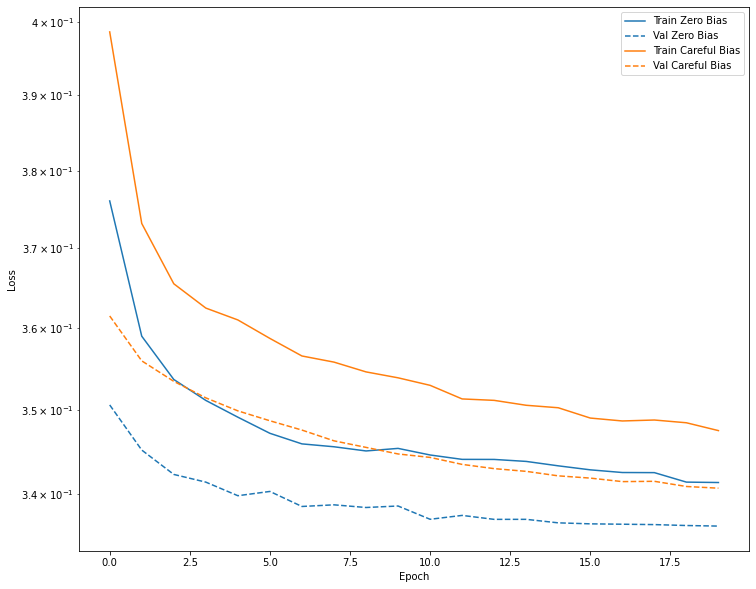

```python
# plot to compare
plot_loss(zero_bias_history, "Zero Bias", 0)
plot_loss(careful_bias_history, "Careful Bias", 1)
```

### Fit the model

```python
model = make_model()
model.load_weights(initial_weights)
risk_history = model.fit(
    train_features,
    train_labels,
    batch_size=BATCH_SIZE,
    epochs=EPOCHS,
    callbacks=[early_stopping],
    validation_data=(val_features, val_labels),
    class_weight=class_weight)
```

[output not shown]

```python
print(model.evaluate(test_features, test_labels))
```

```
[0.6048888564109802, 1449.0, 4898.0, 9402.0, 640.0, 0.6620904207229614, 0.22829683125019073, 0.6936333179473877, 0.736199140548706]
```

### Check training history

```python
def plot_metrics(history):
  metrics = ['loss', 'auc', 'precision', 'recall']
  for n, metric in enumerate(metrics):
    name = metric.replace("_"," ").capitalize()
    plt.subplot(2,2,n+1)
    plt.plot(history.epoch, history.history[metric], color=colors[0], label='Train')
    plt.plot(history.epoch, history.history['val_'+metric],
             color=colors[0], linestyle="--", label='Val')
    plt.xlabel('Epoch')
    plt.ylabel(name)
    if metric == 'loss':
      plt.ylim([0.55, plt.ylim()[1]])
    elif metric == 'auc':
      plt.ylim([0.5,0.8])
    else:
      plt.ylim([0,1])

    plt.legend()
```

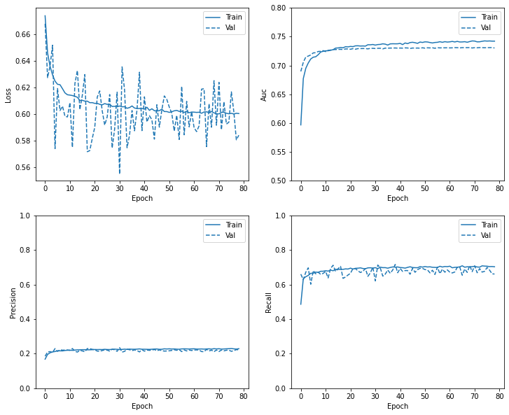

```python
plot_metrics(risk_history)
```

There are a lot of noises in the validation curve in Loss graph, indicating poor performance of the model.

### Evaluate metrics

```python
train_predictions_risk = model.predict(train_features, batch_size=BATCH_SIZE)
test_predictions_risk = model.predict(test_features, batch_size=BATCH_SIZE)
```

Due to the imbalanced data, precision-recall curve is used to evaluate the model.

```python
def plot_prc(name, labels, predictions, **kwargs):
  pr, re, _ = sklearn.metrics.precision_recall_curve(labels, predictions)
  prc_auc = sklearn.metrics.auc(re, pr)
  plt.plot(100*re, 100*pr, linewidth=2, **kwargs, label = name)
  plt.title('AUC = %0.2f' % prc_auc)
  plt.xlabel('Recall')
  plt.ylabel('Precision')
  plt.xlim([-0.5,100])
  plt.ylim([0,100.5])
  plt.grid(True)
  ax = plt.gca()
  ax.set_aspect('equal')
```

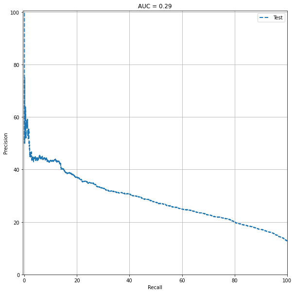

```python
plot_prc("Test", test_labels, test_predictions_risk, color=colors[0], linestyle='--')
plt.legend(loc='upper right')
```

The AUC is pretty low, indicating that the model is not providing a good prediction.

### Try a model with more nodes

```python
METRICS = [
      keras.metrics.TruePositives(name='tp'),
      keras.metrics.FalsePositives(name='fp'),
      keras.metrics.TrueNegatives(name='tn'),
      keras.metrics.FalseNegatives(name='fn'),
      keras.metrics.BinaryAccuracy(name='accuracy'),
      keras.metrics.Precision(name='precision'),
      keras.metrics.Recall(name='recall'),
      keras.metrics.AUC(name='auc'),
]

# Power scheduling
optimizer = keras.optimizers.SGD(lr=0.01, decay=1e-4)

def make_model(metrics=METRICS, optimizer=optimizer, output_bias=None):
  if output_bias is not None:
    output_bias = tf.keras.initializers.Constant(output_bias)
  model = keras.Sequential([
      keras.layers.Dense(2048, activation='relu',
          input_shape=(train_features.shape[-1],)),
      keras.layers.Dropout(0.5),
      #keras.layers.Dense(32, activation='relu'),
      #keras.layers.Dropout(0.2),
      keras.layers.Dense(1, activation='sigmoid',
                         bias_initializer=output_bias),
  ])

  model.compile(
      optimizer=optimizer,
      loss=keras.losses.BinaryCrossentropy(),
      metrics=metrics)

  return model
```

```python
EPOCHS = 200
BATCH_SIZE = 25

early_stopping = tf.keras.callbacks.EarlyStopping(
    monitor='val_auc',
    verbose=1,
    patience=10,
    mode='max',
    restore_best_weights=True)
```

```python
model = make_model()
model.summary()
```

```
Model: "sequential_4"
_________________________________________________________________
Layer (type)                 Output Shape              Param #
=================================================================
dense_8 (Dense)              (None, 2048)              229376
_________________________________________________________________
dropout_4 (Dropout)          (None, 2048)              0
_________________________________________________________________
dense_9 (Dense)              (None, 1)                 2049
=================================================================
Total params: 231,425
Trainable params: 231,425
Non-trainable params: 0
_________________________________________________________________
```

```python
model.predict(train_features[:10])
```

```
array([[0.21684018],
       [0.23907478],
       [0.22676654],
       [0.23878361],
       [0.26380235],
       [0.220355  ],
       [0.19514598],
       [0.21055147],
       [0.20378618],
       [0.19499038]], dtype=float32)
```

```python
initial_weights = os.path.join(tempfile.mkdtemp(), 'initial_weights')
model.save_weights(initial_weights)
```

```python
model = make_model()
model.load_weights(initial_weights)
model.layers[-1].bias.assign([0.0])
zero_bias_history = model.fit(
    train_features,
    train_labels,
    batch_size=BATCH_SIZE,
    epochs=20,
    validation_data=(val_features, val_labels),
    verbose=0)
```

```python
model = make_model()
model.load_weights(initial_weights)
careful_bias_history = model.fit(
    train_features,
    train_labels,
    batch_size=BATCH_SIZE,
    epochs=20,
    validation_data=(val_features, val_labels),
    verbose=0)
```

```python
def plot_loss(history, label, n):
  # Use a log scale to show the wide range of values.
  plt.semilogy(history.epoch, history.history['loss'],
               color=colors[n], label='Train '+label)
  plt.semilogy(history.epoch, history.history['val_loss'],
          color=colors[n], label='Val '+label,
          linestyle="--")
  plt.xlabel('Epoch')
  plt.ylabel('Loss')

  plt.legend()
```

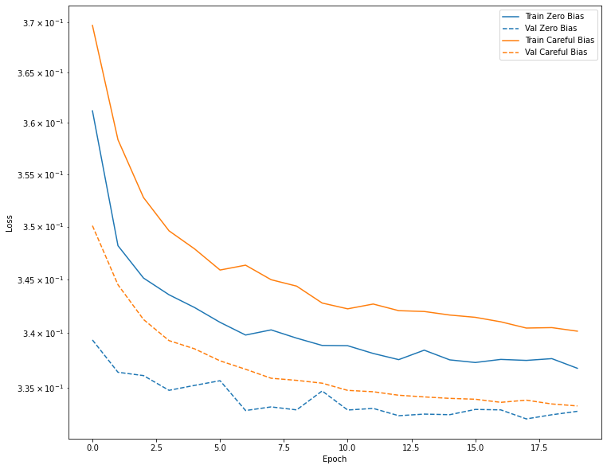

```python
plot_loss(zero_bias_history, "Zero Bias", 0)
plot_loss(careful_bias_history, "Careful Bias", 1)
```

```python
model = make_model()
model.load_weights(initial_weights)
risk_node = model.fit(
    train_features,
    train_labels,
    batch_size=BATCH_SIZE,
    epochs=EPOCHS,
    callbacks=[early_stopping],
    validation_data=(val_features, val_labels),
    class_weight=class_weight)
```

```
Epoch 00065: early stopping
```

```python
def plot_metrics(history):
  metrics = ['loss', 'auc', 'precision', 'recall']
  for n, metric in enumerate(metrics):
    name = metric.replace("_"," ").capitalize()
    plt.subplot(2,2,n+1)
    plt.plot(history.epoch, history.history[metric], color=colors[0], label='Train')
    plt.plot(history.epoch, history.history['val_'+metric],
             color=colors[0], linestyle="--", label='Val')
    plt.xlabel('Epoch')
    plt.ylabel(name)
    if metric == 'loss':
      plt.ylim([0.55, plt.ylim()[1]])
    elif metric == 'auc':
      plt.ylim([0.5,0.8])
    else:
      plt.ylim([0,1])

    plt.legend()
```

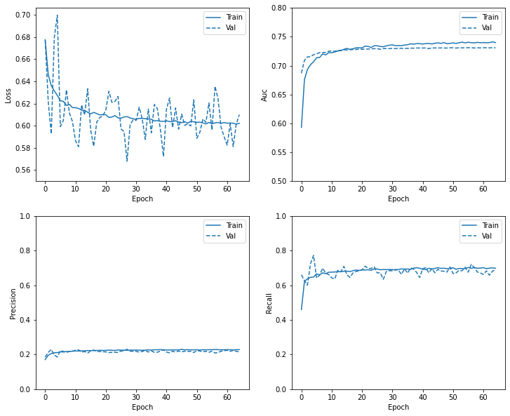

```python
plot_metrics(risk_node)
```

Still a lot of noises in the validation curve of the Loss graph.

```python
train_predictions_risk = model.predict(train_features, batch_size=BATCH_SIZE)
test_predictions_risk = model.predict(test_features, batch_size=BATCH_SIZE)
```

```python
def plot_prc(name, labels, predictions, **kwargs):
  pr, re, _ = sklearn.metrics.precision_recall_curve(labels, predictions)
  prc_auc = sklearn.metrics.auc(re, pr)
  plt.plot(100*re, 100*pr, linewidth=2, **kwargs, label = name)
  plt.title('AUC = %0.2f' % prc_auc)
  plt.xlabel('Recall')
  plt.ylabel('Precision')
  plt.xlim([-0.5,100])
  plt.ylim([0,100.5])
  plt.grid(True)
  ax = plt.gca()
  ax.set_aspect('equal')
```

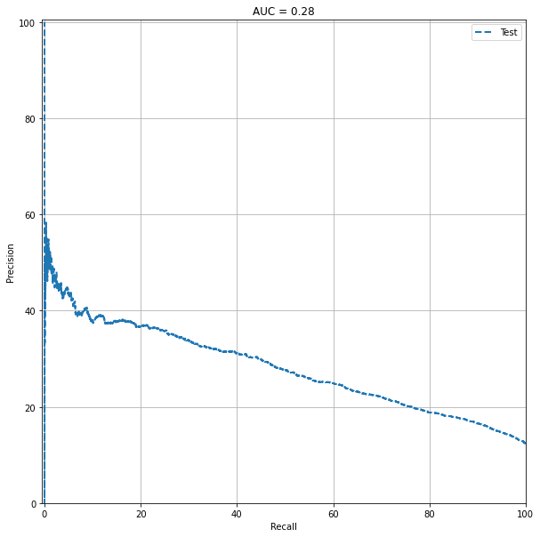

```python
plot_prc("Test", test_labels, test_predictions_risk, color=colors[0], linestyle='--')
plt.legend(loc='upper right')
```

No better than the original model.

### Try a model with more layers

```python
METRICS = [
      keras.metrics.TruePositives(name='tp'),
      keras.metrics.FalsePositives(name='fp'),
      keras.metrics.TrueNegatives(name='tn'),
      keras.metrics.FalseNegatives(name='fn'),
      keras.metrics.BinaryAccuracy(name='accuracy'),
      keras.metrics.Precision(name='precision'),
      keras.metrics.Recall(name='recall'),
      keras.metrics.AUC(name='auc'),
]

# Power scheduling
optimizer = keras.optimizers.SGD(lr=0.01, decay=1e-4)

def make_model(metrics=METRICS, optimizer=optimizer, output_bias=None):
  if output_bias is not None:
    output_bias = tf.keras.initializers.Constant(output_bias)
  model = keras.Sequential([
      keras.layers.Dense(128, activation='relu',
          input_shape=(train_features.shape[-1],)),
      keras.layers.Dropout(0.5),
      keras.layers.Dense(64, activation='relu'),
      keras.layers.Dropout(0.2),
      keras.layers.Dense(1, activation='sigmoid',
                         bias_initializer=output_bias),
  ])

  model.compile(
      optimizer=optimizer,
      loss=keras.losses.BinaryCrossentropy(),
      metrics=metrics)

  return model
```

```python
EPOCHS = 200
BATCH_SIZE = 25

early_stopping = tf.keras.callbacks.EarlyStopping(
    monitor='val_auc',
    verbose=1,
    patience=10,
    mode='max',
    restore_best_weights=True)
```

```python
model = make_model()
model.summary()
```

```
Model: "sequential_8"
_________________________________________________________________
Layer (type)                 Output Shape              Param #
=================================================================
dense_16 (Dense)             (None, 128)               14336
_________________________________________________________________
dropout_8 (Dropout)          (None, 128)               0
_________________________________________________________________
dense_17 (Dense)             (None, 64)                8256
_________________________________________________________________
dropout_9 (Dropout)          (None, 64)                0
_________________________________________________________________
dense_18 (Dense)             (None, 1)                 65
=================================================================
Total params: 22,657
Trainable params: 22,657
Non-trainable params: 0
_________________________________________________________________
```

```python
model.predict(train_features[:10])
```

```
array([[0.5787482 ],
       [0.6829377 ],
       [0.71370786],
       [0.59006584],
       [0.640814  ],
       [0.6411455 ],
       [0.4572869 ],
       [0.55374473],
       [0.42771345],
       [0.37733492]], dtype=float32)
```

```python
initial_weights = os.path.join(tempfile.mkdtemp(), 'initial_weights')
model.save_weights(initial_weights)
```

```python
model = make_model()
model.load_weights(initial_weights)
model.layers[-1].bias.assign([0.0])
zero_bias_history = model.fit(
    train_features,
    train_labels,
    batch_size=BATCH_SIZE,
    epochs=20,
    validation_data=(val_features, val_labels),
    verbose=0)
```

```python
model = make_model()
model.load_weights(initial_weights)
careful_bias_history = model.fit(
    train_features,
    train_labels,
    batch_size=BATCH_SIZE,
    epochs=20,
    validation_data=(val_features, val_labels),
    verbose=0)
```

```python
def plot_loss(history, label, n):
  # Use a log scale to show the wide range of values.
  plt.semilogy(history.epoch, history.history['loss'],
               color=colors[n], label='Train '+label)
  plt.semilogy(history.epoch, history.history['val_loss'],
          color=colors[n], label='Val '+label,
          linestyle="--")
  plt.xlabel('Epoch')
  plt.ylabel('Loss')

  plt.legend()
```

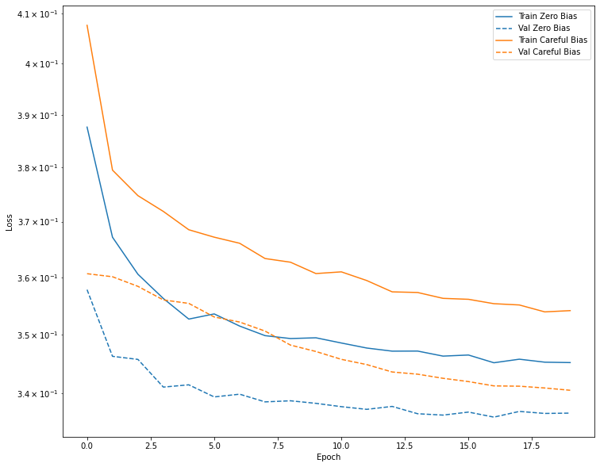

```python
plot_loss(zero_bias_history, "Zero Bias", 0)
plot_loss(careful_bias_history, "Careful Bias", 1)
```

```python
model = make_model()
model.load_weights(initial_weights)
risk_layer = model.fit(
    train_features,
    train_labels,
    batch_size=BATCH_SIZE,
    epochs=EPOCHS,
    callbacks=[early_stopping],
    validation_data=(val_features, val_labels),
    class_weight=class_weight)
```

```
Epoch 00155: early stopping
```

```python
def plot_metrics(history):
  metrics = ['loss', 'auc', 'precision', 'recall']
  for n, metric in enumerate(metrics):
    name = metric.replace("_"," ").capitalize()
    plt.subplot(2,2,n+1)
    plt.plot(history.epoch, history.history[metric], color=colors[0], label='Train')
    plt.plot(history.epoch, history.history['val_'+metric],
             color=colors[0], linestyle="--", label='Val')
    plt.xlabel('Epoch')
    plt.ylabel(name)
    if metric == 'loss':
      plt.ylim([0.50, plt.ylim()[1]])
    elif metric == 'auc':
      plt.ylim([0.5,0.8])
    else:
      plt.ylim([0,1])

    plt.legend()
```

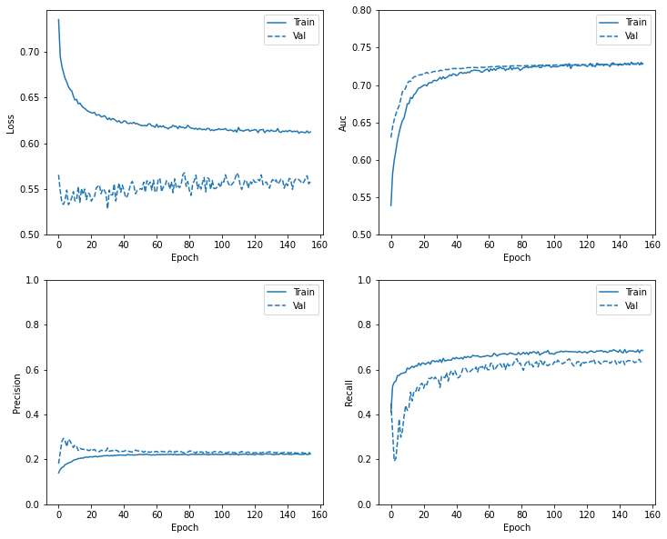

```python
plot_metrics(risk_layer)
```

Worse model based on the Loss graph.The validation curve is constantly lower than the training curve, indicating that the validation dataset may be easier for the model to predict than the training dataset.

```python
train_predictions_risk = model.predict(train_features, batch_size=BATCH_SIZE)
test_predictions_risk = model.predict(test_features, batch_size=BATCH_SIZE)
```

```python
def plot_prc(name, labels, predictions, **kwargs):
  pr, re, _ = sklearn.metrics.precision_recall_curve(labels, predictions)
  prc_auc = sklearn.metrics.auc(re, pr)
  plt.plot(100*re, 100*pr, linewidth=2, **kwargs, label = name)
  plt.title('AUC = %0.2f' % prc_auc)
  plt.xlabel('Recall')
  plt.ylabel('Precision')
  plt.xlim([-0.5,100])
  plt.ylim([0,100.5])
  plt.grid(True)
  ax = plt.gca()
  ax.set_aspect('equal')
```

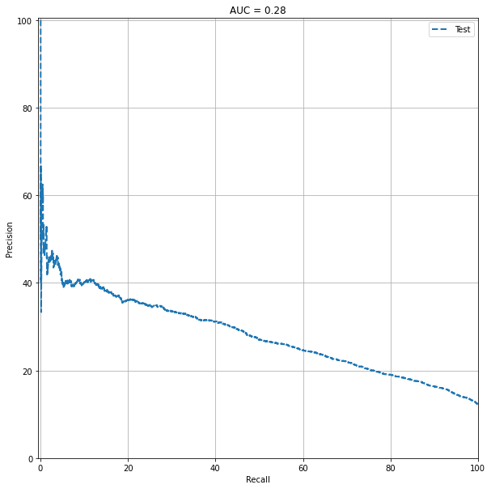

```python
plot_prc("Test", test_labels, test_predictions_risk, color=colors[0], linestyle='--')
plt.legend(loc='upper right')
```

No better than the original model based on AUC.

### Try single layer with less nodes.

```python
METRICS = [
      keras.metrics.TruePositives(name='tp'),
      keras.metrics.FalsePositives(name='fp'),
      keras.metrics.TrueNegatives(name='tn'),
      keras.metrics.FalseNegatives(name='fn'),
      keras.metrics.BinaryAccuracy(name='accuracy'),
      keras.metrics.Precision(name='precision'),
      keras.metrics.Recall(name='recall'),
      keras.metrics.AUC(name='auc'),
]

# Power scheduling
optimizer = keras.optimizers.SGD(lr=0.01, decay=1e-4)

def make_model(metrics=METRICS, optimizer=optimizer, output_bias=None):
  if output_bias is not None:
    output_bias = tf.keras.initializers.Constant(output_bias)
  model = keras.Sequential([
      keras.layers.Dense(32, activation='relu',
          input_shape=(train_features.shape[-1],)),
      keras.layers.Dropout(0.5),
      keras.layers.Dense(1, activation='sigmoid',
                         bias_initializer=output_bias),
  ])

  model.compile(
      optimizer=optimizer,
      loss=keras.losses.BinaryCrossentropy(),
      metrics=metrics)

  return model
```

```python
EPOCHS = 200
BATCH_SIZE = 25

early_stopping = tf.keras.callbacks.EarlyStopping(
    monitor='val_auc',
    verbose=1,
    patience=10,
    mode='max',
    restore_best_weights=True)
```

```python
model = make_model()
model.summary()
```

```
Model: "sequential_12"
_________________________________________________________________
Layer (type)                 Output Shape              Param #
=================================================================
dense_28 (Dense)             (None, 32)                3584
_________________________________________________________________
dropout_16 (Dropout)         (None, 32)                0
_________________________________________________________________
dense_29 (Dense)             (None, 1)                 33
=================================================================
Total params: 3,617
Trainable params: 3,617
Non-trainable params: 0
_________________________________________________________________
```

```python
model.predict(train_features[:10])
```

```
array([[0.4824587 ],
       [0.56674784],
       [0.5254122 ],
       [0.77716017],
       [0.555823  ],
       [0.8107454 ],
       [0.56536645],
       [0.522626  ],
       [0.78009385],
       [0.748886  ]], dtype=float32)
```

```python
initial_weights = os.path.join(tempfile.mkdtemp(), 'initial_weights')
model.save_weights(initial_weights)
```

```python
model = make_model()
model.load_weights(initial_weights)
model.layers[-1].bias.assign([0.0])
zero_bias_history = model.fit(
    train_features,
    train_labels,
    batch_size=BATCH_SIZE,
    epochs=20,
    validation_data=(val_features, val_labels),
    verbose=0)
```

```python
model = make_model()
model.load_weights(initial_weights)
careful_bias_history = model.fit(
    train_features,
    train_labels,
    batch_size=BATCH_SIZE,
    epochs=20,
    validation_data=(val_features, val_labels),
    verbose=0)
```

```python
def plot_loss(history, label, n):
  # Use a log scale to show the wide range of values.
  plt.semilogy(history.epoch, history.history['loss'],
               color=colors[n], label='Train '+label)
  plt.semilogy(history.epoch, history.history['val_loss'],
          color=colors[n], label='Val '+label,
          linestyle="--")
  plt.xlabel('Epoch')
  plt.ylabel('Loss')

  plt.legend()
```

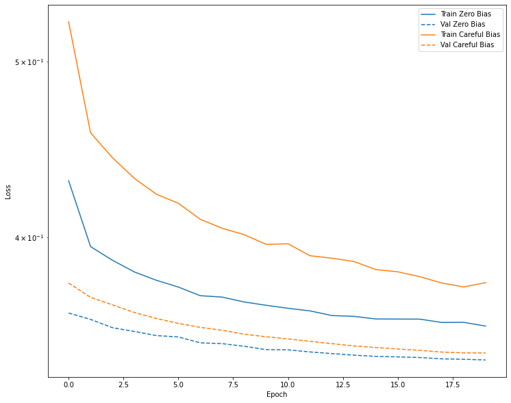

```python
plot_loss(zero_bias_history, "Zero Bias", 0)
plot_loss(careful_bias_history, "Careful Bias", 1)
```

```python
model = make_model()
model.load_weights(initial_weights)
risk_lnodes = model.fit(
    train_features,
    train_labels,
    batch_size=BATCH_SIZE,
    epochs=EPOCHS,
    callbacks=[early_stopping],
    validation_data=(val_features, val_labels),
    class_weight=class_weight)
```

```
Epoch 00106: early stopping
```

```python
def plot_metrics(history):
  metrics = ['loss', 'auc', 'precision', 'recall']
  for n, metric in enumerate(metrics):
    name = metric.replace("_"," ").capitalize()
    plt.subplot(2,2,n+1)
    plt.plot(history.epoch, history.history[metric], color=colors[0], label='Train')
    plt.plot(history.epoch, history.history['val_'+metric],
             color=colors[0], linestyle="--", label='Val')
    plt.xlabel('Epoch')
    plt.ylabel(name)
    if metric == 'loss':
      plt.ylim([0.55, plt.ylim()[1]])
    elif metric == 'auc':
      plt.ylim([0.5,0.8])
    else:
      plt.ylim([0,1])

    plt.legend()
```

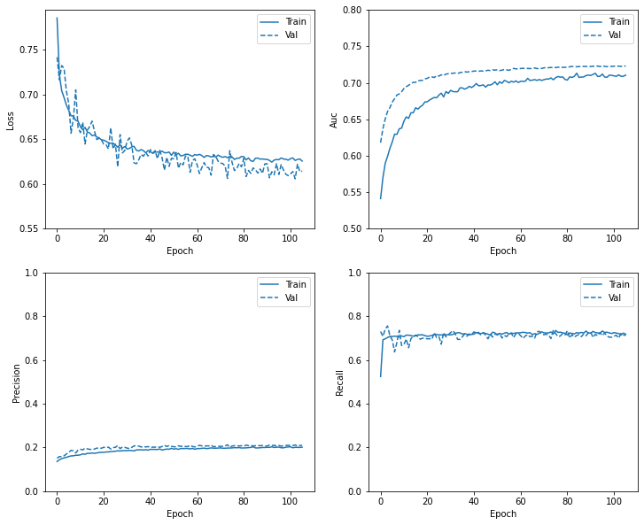

```python
plot_metrics(risk_lnodes)
```

```python
train_predictions_risk = model.predict(train_features, batch_size=BATCH_SIZE)
test_predictions_risk = model.predict(test_features, batch_size=BATCH_SIZE)
```

```python
def plot_prc(name, labels, predictions, **kwargs):
  pr, re, _ = sklearn.metrics.precision_recall_curve(labels, predictions)
  prc_auc = sklearn.metrics.auc(re, pr)
  plt.plot(100*re, 100*pr, linewidth=2, **kwargs, label = name)
  plt.title('AUC = %0.2f' % prc_auc)
  plt.xlabel('Recall')
  plt.ylabel('Precision')
  plt.xlim([-0.5,100])
  plt.ylim([0,100.5])
  plt.grid(True)
  ax = plt.gca()
  ax.set_aspect('equal')
```

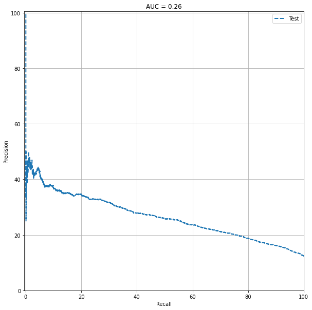

```python
plot_prc("Test", test_labels, test_predictions_risk, color=colors[0], linestyle='--')
plt.legend(loc='upper right')
```

Loss graph seems better than the original, but AUC is worse.

### Try number of nodes somewhere in between

```python
METRICS = [
      keras.metrics.TruePositives(name='tp'),
      keras.metrics.FalsePositives(name='fp'),
      keras.metrics.TrueNegatives(name='tn'),
      keras.metrics.FalseNegatives(name='fn'),
      keras.metrics.BinaryAccuracy(name='accuracy'),
      keras.metrics.Precision(name='precision'),
      keras.metrics.Recall(name='recall'),
      keras.metrics.AUC(name='auc'),
]

# Power scheduling
optimizer = keras.optimizers.SGD(lr=0.01, decay=1e-4)

def make_model(metrics=METRICS, optimizer=optimizer, output_bias=None):
  if output_bias is not None:
    output_bias = tf.keras.initializers.Constant(output_bias)
  model = keras.Sequential([
      keras.layers.Dense(64, activation='relu',
          input_shape=(train_features.shape[-1],)),
      keras.layers.Dropout(0.5),
      keras.layers.Dense(1, activation='sigmoid',
                         bias_initializer=output_bias),
  ])

  model.compile(
      optimizer=optimizer,
      loss=keras.losses.BinaryCrossentropy(),
      metrics=metrics)

  return model
```

```python
EPOCHS = 200
BATCH_SIZE = 25

early_stopping = tf.keras.callbacks.EarlyStopping(
    monitor='val_auc',
    verbose=1,
    patience=10,
    mode='max',
    restore_best_weights=True)
```

```python
model = make_model()
model.summary()
```

```
Model: "sequential_18"
_________________________________________________________________
Layer (type)                 Output Shape              Param #
=================================================================
dense_40 (Dense)             (None, 64)                7168
_________________________________________________________________
dropout_22 (Dropout)         (None, 64)                0
_________________________________________________________________
dense_41 (Dense)             (None, 1)                 65
=================================================================
Total params: 7,233
Trainable params: 7,233
Non-trainable params: 0
_________________________________________________________________
```

```python
model.predict(train_features[:10])
```

```
array([[0.5291861 ],
       [0.9770223 ],
       [0.98631555],
       [0.98352516],
       [0.9787653 ],
       [0.99272436],
       [0.86753166],
       [0.93681824],
       [0.86438584],
       [0.88656837]], dtype=float32)
```

```python
initial_weights = os.path.join(tempfile.mkdtemp(), 'initial_weights')
model.save_weights(initial_weights)
```

```python
model = make_model()
model.load_weights(initial_weights)
model.layers[-1].bias.assign([0.0])
zero_bias_history = model.fit(
    train_features,
    train_labels,
    batch_size=BATCH_SIZE,
    epochs=20,
    validation_data=(val_features, val_labels),
    verbose=0)
```

```python
model = make_model()
model.load_weights(initial_weights)
careful_bias_history = model.fit(
    train_features,
    train_labels,
    batch_size=BATCH_SIZE,
    epochs=20,
    validation_data=(val_features, val_labels),
    verbose=0)
```

```python
def plot_loss(history, label, n):
  # Use a log scale to show the wide range of values.
  plt.semilogy(history.epoch, history.history['loss'],
               color=colors[n], label='Train '+label)
  plt.semilogy(history.epoch, history.history['val_loss'],
          color=colors[n], label='Val '+label,
          linestyle="--")
  plt.xlabel('Epoch')
  plt.ylabel('Loss')

  plt.legend()
```

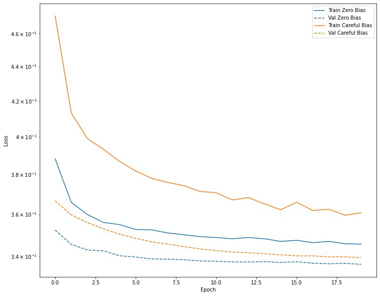

```python
plot_loss(zero_bias_history, "Zero Bias", 0)
plot_loss(careful_bias_history, "Careful Bias", 1)
```

```python
model = make_model()
model.load_weights(initial_weights)
risk_lnodes2 = model.fit(
    train_features,
    train_labels,
    batch_size=BATCH_SIZE,
    epochs=EPOCHS,
    callbacks=[early_stopping],
    validation_data=(val_features, val_labels),
    class_weight=class_weight)
```

```
Epoch 00105: early stopping
```

```python
def plot_metrics(history):
  metrics = ['loss', 'auc', 'precision', 'recall']
  for n, metric in enumerate(metrics):
    name = metric.replace("_"," ").capitalize()
    plt.subplot(2,2,n+1)
    plt.plot(history.epoch, history.history[metric], color=colors[0], label='Train')
    plt.plot(history.epoch, history.history['val_'+metric],
             color=colors[0], linestyle="--", label='Val')
    plt.xlabel('Epoch')
    plt.ylabel(name)
    if metric == 'loss':
      plt.ylim([0.55, plt.ylim()[1]])
    elif metric == 'auc':
      plt.ylim([0.5,0.8])
    else:
      plt.ylim([0,1])

    plt.legend()
```

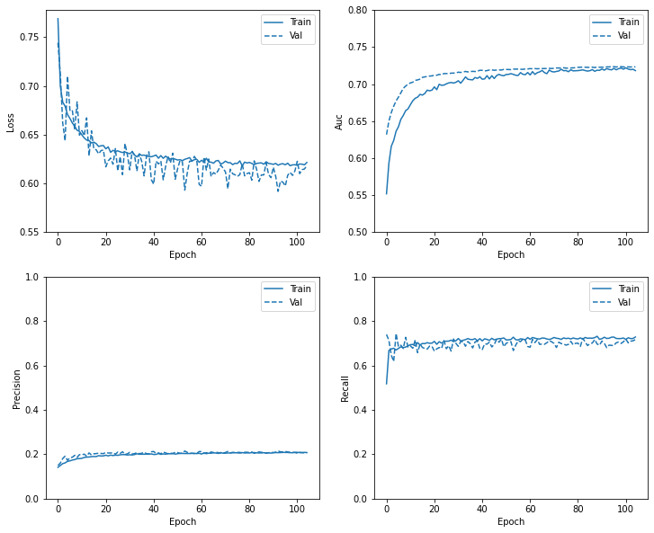

```python
plot_metrics(risk_lnodes2)
```

```python
train_predictions_risk = model.predict(train_features, batch_size=BATCH_SIZE)
test_predictions_risk = model.predict(test_features, batch_size=BATCH_SIZE)
```

```python
def plot_prc(name, labels, predictions, **kwargs):
  pr, re, _ = sklearn.metrics.precision_recall_curve(labels, predictions)
  prc_auc = sklearn.metrics.auc(re, pr)
  plt.plot(100*re, 100*pr, linewidth=2, **kwargs, label = name)
  plt.title('AUC = %0.2f' % prc_auc)
  plt.xlabel('Recall')
  plt.ylabel('Precision')
  plt.xlim([-0.5,100])
  plt.ylim([0,100.5])
  plt.grid(True)
  ax = plt.gca()
  ax.set_aspect('equal')
```

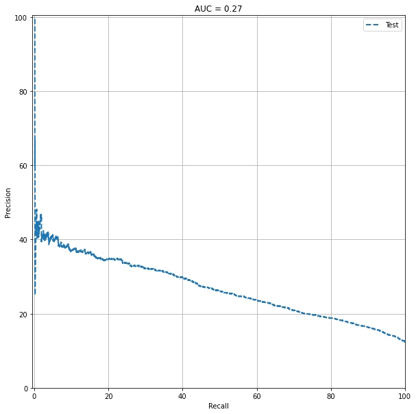

```python
plot_prc("Test", test_labels, test_predictions_risk, color=colors[0], linestyle='--')
plt.legend(loc='upper right')
```

The AUC is increasing from the previous model. Even it is still lower than the original model.

### Try inrease the number of nodes.

```python
METRICS = [
      keras.metrics.TruePositives(name='tp'),
      keras.metrics.FalsePositives(name='fp'),
      keras.metrics.TrueNegatives(name='tn'),
      keras.metrics.FalseNegatives(name='fn'),
      keras.metrics.BinaryAccuracy(name='accuracy'),
      keras.metrics.Precision(name='precision'),
      keras.metrics.Recall(name='recall'),
      keras.metrics.AUC(name='auc'),
]

# Power scheduling
optimizer = keras.optimizers.SGD(lr=0.01, decay=1e-4)

def make_model(metrics=METRICS, optimizer=optimizer, output_bias=None):
  if output_bias is not None:
    output_bias = tf.keras.initializers.Constant(output_bias)
  model = keras.Sequential([
      keras.layers.Dense(96, activation='relu',
          input_shape=(train_features.shape[-1],)),
      keras.layers.Dropout(0.5),
      keras.layers.Dense(1, activation='sigmoid',
                         bias_initializer=output_bias),
  ])

  model.compile(
      optimizer=optimizer,
      loss=keras.losses.BinaryCrossentropy(),
      metrics=metrics)

  return model
```

```python
EPOCHS = 200
BATCH_SIZE = 25

early_stopping = tf.keras.callbacks.EarlyStopping(
    monitor='val_auc',
    verbose=1,
    patience=10,
    mode='max',
    restore_best_weights=True)
```

```python
model = make_model()
model.summary()
```

```
Model: "sequential_22"
_________________________________________________________________
Layer (type)                 Output Shape              Param #
=================================================================
dense_48 (Dense)             (None, 96)                10752
_________________________________________________________________
dropout_26 (Dropout)         (None, 96)                0
_________________________________________________________________
dense_49 (Dense)             (None, 1)                 97
=================================================================
Total params: 10,849
Trainable params: 10,849
Non-trainable params: 0
_________________________________________________________________
```

```python
model.predict(train_features[:10])
```

```
array([[0.26894304],
       [0.22043884],
       [0.21831012],
       [0.18525799],
       [0.20157988],
       [0.7656054 ],
       [0.46023673],
       [0.44154325],
       [0.5773883 ],
       [0.562634  ]], dtype=float32)
```

```python
initial_weights = os.path.join(tempfile.mkdtemp(), 'initial_weights')
model.save_weights(initial_weights)
```

```python
model = make_model()
model.load_weights(initial_weights)
model.layers[-1].bias.assign([0.0])
zero_bias_history = model.fit(
    train_features,
    train_labels,
    batch_size=BATCH_SIZE,
    epochs=20,
    validation_data=(val_features, val_labels),
    verbose=0)
```

```python
model = make_model()
model.load_weights(initial_weights)
careful_bias_history = model.fit(
    train_features,
    train_labels,
    batch_size=BATCH_SIZE,
    epochs=20,
    validation_data=(val_features, val_labels),
    verbose=0)
```

```python
def plot_loss(history, label, n):
  # Use a log scale to show the wide range of values.
  plt.semilogy(history.epoch, history.history['loss'],
               color=colors[n], label='Train '+label)
  plt.semilogy(history.epoch, history.history['val_loss'],
          color=colors[n], label='Val '+label,
          linestyle="--")
  plt.xlabel('Epoch')
  plt.ylabel('Loss')

  plt.legend()
```

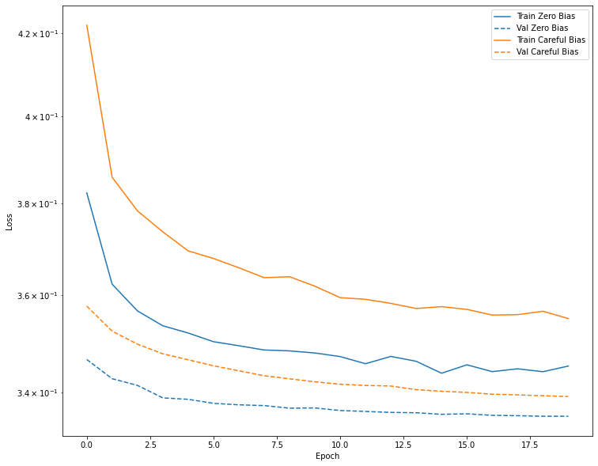

```python
plot_loss(zero_bias_history, "Zero Bias", 0)
plot_loss(careful_bias_history, "Careful Bias", 1)
```

```python
model = make_model()
model.load_weights(initial_weights)
risk_lnodes3 = model.fit(
    train_features,
    train_labels,
    batch_size=BATCH_SIZE,
    epochs=EPOCHS,
    callbacks=[early_stopping],
    validation_data=(val_features, val_labels),
    class_weight=class_weight)
```

```
Epoch 00072: early stopping
```

```python
def plot_metrics(history):
  metrics = ['loss', 'auc', 'precision', 'recall']
  for n, metric in enumerate(metrics):
    name = metric.replace("_"," ").capitalize()
    plt.subplot(2,2,n+1)
    plt.plot(history.epoch, history.history[metric], color=colors[0], label='Train')
    plt.plot(history.epoch, history.history['val_'+metric],
             color=colors[0], linestyle="--", label='Val')
    plt.xlabel('Epoch')
    plt.ylabel(name)
    if metric == 'loss':
      plt.ylim([0.55, plt.ylim()[1]])
    elif metric == 'auc':
      plt.ylim([0.5,0.8])
    else:
      plt.ylim([0,1])

    plt.legend()
```

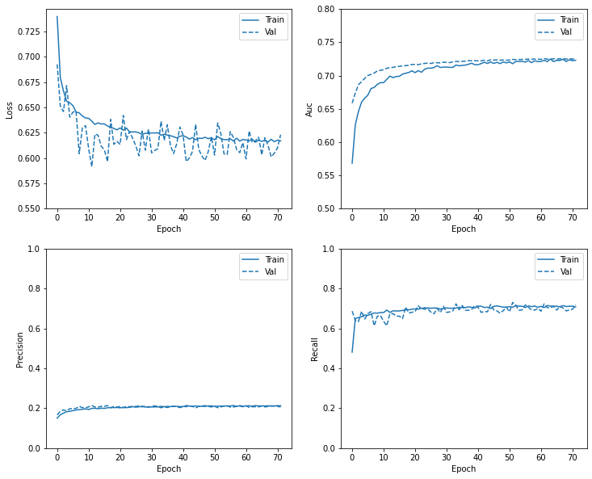

```python
plot_metrics(risk_lnodes3)
```

```python
train_predictions_risk = model.predict(train_features, batch_size=BATCH_SIZE)
test_predictions_risk = model.predict(test_features, batch_size=BATCH_SIZE)
```

```python
def plot_prc(name, labels, predictions, **kwargs):
  pr, re, _ = sklearn.metrics.precision_recall_curve(labels, predictions)
  prc_auc = sklearn.metrics.auc(re, pr)
  plt.plot(100*re, 100*pr, linewidth=2, **kwargs, label = name)
  plt.title('AUC = %0.2f' % prc_auc)
  plt.xlabel('Recall')
  plt.ylabel('Precision')
  plt.xlim([-0.5,100])
  plt.ylim([0,100.5])
  plt.grid(True)
  ax = plt.gca()
  ax.set_aspect('equal')
```

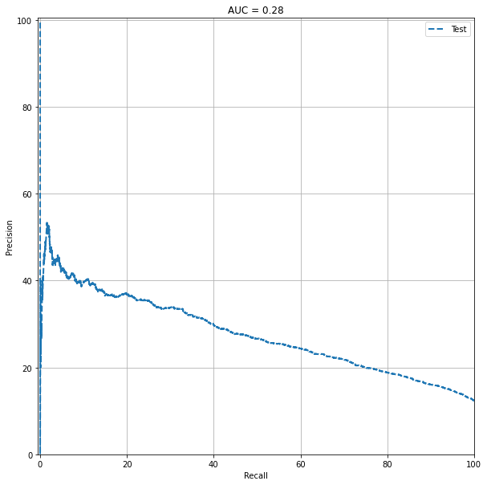

```python
plot_prc("Test", test_labels, test_predictions_risk, color=colors[0], linestyle='--')
plt.legend(loc='upper right')
```

## Try Random Forest

```python
# random forest for imbalanced classification
from numpy import mean
from sklearn.datasets import make_classification
from sklearn.model_selection import cross_val_score
from sklearn.model_selection import RepeatedStratifiedKFold
from sklearn.ensemble import RandomForestClassifier
```

```python
# generate data
df_labels = np.array(df.pop('hivrisk5'))
df_features = np.array(df)
```

```python
# define model
# to adjust for imbalanced data, class_weight is used
# Given that each decision tree is constructed from a bootstrap sample,
# the class weighting is based on the class distribution in each bootstrap sample
model = RandomForestClassifier(n_estimators=10, class_weight='balanced_subsample')
# define evaluation procedure
cv = RepeatedStratifiedKFold(n_splits=10, n_repeats=3, random_state=1)
```

```python
sorted(sklearn.metrics.SCORERS.keys())
```

```
['accuracy',
 'adjusted_mutual_info_score',
 'adjusted_rand_score',
 'average_precision',
 'balanced_accuracy',
 'completeness_score',
 'explained_variance',
 'f1',
 'f1_macro',
 'f1_micro',
 'f1_samples',
 'f1_weighted',
 'fowlkes_mallows_score',
 'homogeneity_score',
 'jaccard',
 'jaccard_macro',
 'jaccard_micro',
 'jaccard_samples',
 'jaccard_weighted',
 'max_error',
 'mutual_info_score',
 'neg_brier_score',
 'neg_log_loss',
 'neg_mean_absolute_error',
 'neg_mean_gamma_deviance',
 'neg_mean_poisson_deviance',
 'neg_mean_squared_error',
 'neg_mean_squared_log_error',
 'neg_median_absolute_error',
 'neg_root_mean_squared_error',
 'normalized_mutual_info_score',
 'precision',
 'precision_macro',
 'precision_micro',
 'precision_samples',
 'precision_weighted',
 'r2',
 'recall',
 'recall_macro',
 'recall_micro',
 'recall_samples',
 'recall_weighted',
 'roc_auc',
 'roc_auc_ovo',
 'roc_auc_ovo_weighted',
 'roc_auc_ovr',
 'roc_auc_ovr_weighted',
 'v_measure_score']
```

```python
# evaluate model
accuracy = cross_val_score(model, df_features, df_labels, scoring='accuracy', cv=cv, n_jobs=-1)
precision = cross_val_score(model, df_features, df_labels, scoring='precision', cv=cv, n_jobs=-1)
recall = cross_val_score(model, df_features, df_labels, scoring='recall', cv=cv, n_jobs=-1)
# auc = sklearn.metrics.auc(recall, precision)
# summarize performance
print('Mean Accuracy: %.3f' % mean(accuracy))
print('Mean Precision: %.3f' % mean(precision))
print('Mean Recall: %.3f' % mean(recall))
# print('Mean PRC AUC: %.3f' % mean(auc))
```

```
Mean Accuracy: 0.873
Mean Precision: 0.330
Mean Recall: 0.027
```

Both accuracy and precision from random forest are better than the results from deep neural network. For this outcome of interest, the traditional machine learning technique had better prediction. However, overall the prediction is still not ideal. More model tuning or other methods may be used to provide a better prediction for the identification of those who performed HIV risk behaviors to target future interventions.

## Outcome 2: HIV testing

```python
df2 = pd.read_csv('testfull.csv')
print(df2.head())
```

```
   x.state1  x.state2  x.state4  x.state5  x.state6  x.state8  x.state9  \
0         1         0         0         0         0         0         0
1         1         0         0         0         0         0         0
2         1         0         0         0         0         0         0
3         1         0         0         0         0         0         0
4         1         0         0         0         0         0         0

   x.state10  x.state11  x.state12  ...  x.aidtst4  persdoc  medcost2  \
0          0          0          0  ...          0        0         0
1          0          0          0  ...          0        0         0
2          0          0          0  ...          0        1         0
3          0          0          0  ...          1        1         0
4          0          0          0  ...          0        1         0

   cvdinfr  cvdstrk  diabete  renthom  veteran  decide2  x.urbstat2
0        0        0        0        1        0        0           1
1        0        0        0        1        0        0           1
2        0        0        0        1        0        0           1
3        0        0        0        1        0        0           1
4        0        0        0        1        0        0           0

[5 rows x 112 columns]
```

```python
# Examine the imbalance
neg, pos = np.bincount(df2['x.aidtst4'])
total = neg + pos
print('Examples:\n    Total: {}\n    Positive: {} ({:.2f}% of total)\n'.format(
    total, pos, 100 * pos / total))
```

```
Examples:
    Total: 80166
    Positive: 39521 (49.30% of total)
```

Quite balanced. No need to adjust for imbalance results.

```python
# Log transform the four continuous variables to reduce its range
eps = 0.001
df2['logdrnk'] = np.log(df2.pop('x.drnkwk1')+eps)
df2['logfru'] = np.log(df2.pop('x.frutsu1')+eps)
df2['logveg'] = np.log(df2.pop('x.vegesu1')+eps)
df2['logpa'] = np.log(df2.pop('pa2vigm.')+eps)
```

```python
train2, test2 = train_test_split(df2, test_size=0.2)
train2, val2 = train_test_split(train2, test_size=0.2)
print(len(train2), 'train examples')
print(len(val2), 'validation examples')
print(len(test2), 'test examples')
```

```
51305 train examples
12827 validation examples
16034 test examples
```

```python
# Form np arrays of labels and features.
train_labels2 = np.array(train2.pop('x.aidtst4'))
bool_train_labels2 = train_labels2 != 0
val_labels2 = np.array(val2.pop('x.aidtst4'))
test_labels2 = np.array(test2.pop('x.aidtst4'))

train_features2 = np.array(train2)
val_features2 = np.array(val2)
test_features2 = np.array(test2)
```

```python
print('Training labels shape:', train_labels2.shape)
print('Validation labels shape:', val_labels2.shape)
print('Test labels shape:', test_labels2.shape)

print('Training features shape:', train_features2.shape)
print('Validation features shape:', val_features2.shape)
print('Test features shape:', test_features2.shape)
```

```
Training labels shape: (51305,)
Validation labels shape: (12827,)
Test labels shape: (16034,)
Training features shape: (51305, 111)
Validation features shape: (12827, 111)
Test features shape: (16034, 111)
```

```python
METRICS = [
      keras.metrics.TruePositives(name='tp'),
      keras.metrics.FalsePositives(name='fp'),
      keras.metrics.TrueNegatives(name='tn'),
      keras.metrics.FalseNegatives(name='fn'),
      keras.metrics.BinaryAccuracy(name='accuracy'),
      keras.metrics.Precision(name='precision'),
      keras.metrics.Recall(name='recall'),
      keras.metrics.AUC(name='auc'),
]

# Power scheduling
optimizer = keras.optimizers.SGD(lr=0.01, decay=1e-4)

def make_model(metrics=METRICS, optimizer=optimizer, output_bias=None):
  if output_bias is not None:
    output_bias = tf.keras.initializers.Constant(output_bias)
  model = keras.Sequential([
      keras.layers.Dense(16, activation='relu',
          input_shape=(train_features2.shape[-1],)),
      keras.layers.Dropout(0.5),
      keras.layers.Dense(1, activation='sigmoid',
                         bias_initializer=output_bias),
  ])

  model.compile(
      optimizer=optimizer,
      loss=keras.losses.BinaryCrossentropy(),
      metrics=metrics)

  return model
```

```python
EPOCHS = 100
BATCH_SIZE = 25

early_stopping = tf.keras.callbacks.EarlyStopping(
    monitor='val_auc',
    verbose=1,
    patience=10,
    mode='max',
    restore_best_weights=True)
```

```python
model = make_model()
model.summary()
```

```
Model: "sequential_13"
_________________________________________________________________
Layer (type)                 Output Shape              Param #
=================================================================
dense_28 (Dense)             (None, 16)                1792
_________________________________________________________________
dropout_14 (Dropout)         (None, 16)                0
_________________________________________________________________
dense_29 (Dense)             (None, 1)                 17
=================================================================
Total params: 1,809
Trainable params: 1,809
Non-trainable params: 0
_________________________________________________________________
```

```python
model.predict(train_features2[:10])
```

```
array([[0.19502263],
       [0.15788525],
       [0.2662718 ],
       [0.14758374],
       [0.24742429],
       [0.15021057],
       [0.28203508],
       [0.2521094 ],
       [0.16051558],
       [0.3257407 ]], dtype=float32)
```

```python
initial_weights = os.path.join(tempfile.mkdtemp(), 'initial_weights')
model.save_weights(initial_weights)
```

```python
model = make_model()
model.load_weights(initial_weights)
test_history = model.fit(
    train_features2,
    train_labels2,
    batch_size=BATCH_SIZE,
    epochs=EPOCHS,
    callbacks=[early_stopping],
    validation_data=(val_features2, val_labels2))
```

### Check training history

```python
def plot_metrics(history):
  metrics = ['loss', 'auc', 'precision', 'recall']
  for n, metric in enumerate(metrics):
    name = metric.replace("_"," ").capitalize()
    plt.subplot(2,2,n+1)
    plt.plot(history.epoch, history.history[metric], color=colors[0], label='Train')
    plt.plot(history.epoch, history.history['val_'+metric],
             color=colors[0], linestyle="--", label='Val')
    plt.xlabel('Epoch')
    plt.ylabel(name)
    if metric == 'loss':
      plt.ylim([0.55, plt.ylim()[1]])
    elif metric == 'auc':
      plt.ylim([0.5,0.8])
    else:
      plt.ylim([0,1])

    plt.legend()
```

[figure not shown]

```python
plot_metrics(test_history)
```

The validation curve is constantly lower than the training curve in the Loss graph, suggesting room for improvements in model tuning.

### Evaluate metrics

Given the nature of the data, ROC curve is used here.

```python
train_predictions_test = model.predict(train_features2, batch_size=BATCH_SIZE)
test_predictions_test = model.predict(test_features2, batch_size=BATCH_SIZE)
```

```python
def plot_roc(name, labels, predictions, **kwargs):
  fp, tp, _ = sklearn.metrics.roc_curve(labels, predictions)
  roc_auc = sklearn.metrics.auc(fp, tp)
  plt.plot(100*fp, 100*tp, linewidth=2, **kwargs, label = name)
  plt.title('AUC = %0.2f' % roc_auc)
  plt.xlabel('False positives [%]')
  plt.ylabel('True positives [%]')
  plt.xlim([-0.5,100])
  plt.ylim([0,100.5])
  plt.grid(True)
  ax = plt.gca()
  ax.set_aspect('equal')
```

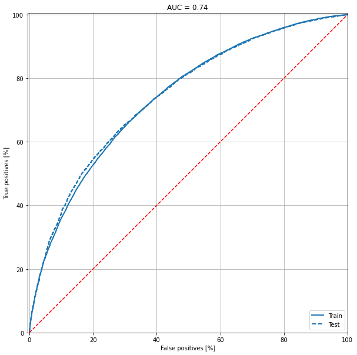

```python
plot_roc("Train", train_labels2, train_predictions_test, color=colors[0])
plot_roc("Test", test_labels2, test_predictions_test, color=colors[0], linestyle='--')
plt.legend(loc='lower right')
plt.plot([0, 100], [0, 100],'r--')
```

The AUC is 0.74, a acceptable discrimination. However, the gap between the training and validation curves in the Loss graph is alarming and shows room for improvement in model tuning.

### Try more nodes

```python
METRICS = [
      keras.metrics.TruePositives(name='tp'),
      keras.metrics.FalsePositives(name='fp'),
      keras.metrics.TrueNegatives(name='tn'),
      keras.metrics.FalseNegatives(name='fn'),
      keras.metrics.BinaryAccuracy(name='accuracy'),
      keras.metrics.Precision(name='precision'),
      keras.metrics.Recall(name='recall'),
      keras.metrics.AUC(name='auc'),
]

# Power scheduling
optimizer = keras.optimizers.SGD(lr=0.01, decay=1e-4)

def make_model(metrics=METRICS, optimizer=optimizer, output_bias=None):
  if output_bias is not None:
    output_bias = tf.keras.initializers.Constant(output_bias)
  model = keras.Sequential([
      keras.layers.Dense(128, activation='relu',
          input_shape=(train_features2.shape[-1],)),
      keras.layers.Dropout(0.5),
      keras.layers.Dense(1, activation='sigmoid',
                         bias_initializer=output_bias),
  ])

  model.compile(
      optimizer=optimizer,
      loss=keras.losses.BinaryCrossentropy(),
      metrics=metrics)

  return model
```

```python
EPOCHS = 200
BATCH_SIZE = 25

early_stopping = tf.keras.callbacks.EarlyStopping(
    monitor='val_auc',
    verbose=1,
    patience=10,
    mode='max',
    restore_best_weights=True)
```

```python
model = make_model()
model.summary()
```

```
Model: "sequential_28"
_________________________________________________________________
Layer (type)                 Output Shape              Param #
=================================================================
dense_60 (Dense)             (None, 128)               14336
_________________________________________________________________
dropout_32 (Dropout)         (None, 128)               0
_________________________________________________________________
dense_61 (Dense)             (None, 1)                 129
=================================================================
Total params: 14,465
Trainable params: 14,465
Non-trainable params: 0
_________________________________________________________________
```

```python
model.predict(train_features2[:10])
```

```
array([[0.37638816],
       [0.2900211 ],
       [0.35665748],
       [0.36862072],
       [0.33388707],
       [0.67089915],
       [0.39507818],
       [0.5053786 ],
       [0.6537374 ],
       [0.36111504]], dtype=float32)
```

```python
initial_weights = os.path.join(tempfile.mkdtemp(), 'initial_weights')
model.save_weights(initial_weights)
```

```python
model = make_model()
model.load_weights(initial_weights)
test_node = model.fit(
    train_features2,
    train_labels2,
    batch_size=BATCH_SIZE,
    epochs=EPOCHS,
    callbacks=[early_stopping],
    validation_data=(val_features2, val_labels2))
```

```
Epoch 00185: early stopping
```

```python
def plot_metrics(history):
  metrics = ['loss', 'auc', 'precision', 'recall']
  for n, metric in enumerate(metrics):
    name = metric.replace("_"," ").capitalize()
    plt.subplot(2,2,n+1)
    plt.plot(history.epoch, history.history[metric], color=colors[0], label='Train')
    plt.plot(history.epoch, history.history['val_'+metric],
             color=colors[0], linestyle="--", label='Val')
    plt.xlabel('Epoch')
    plt.ylabel(name)
    if metric == 'loss':
      plt.ylim([0.58, plt.ylim()[1]])
    elif metric == 'auc':
      plt.ylim([0.55,0.8])
    else:
      plt.ylim([0,1])

    plt.legend()
```

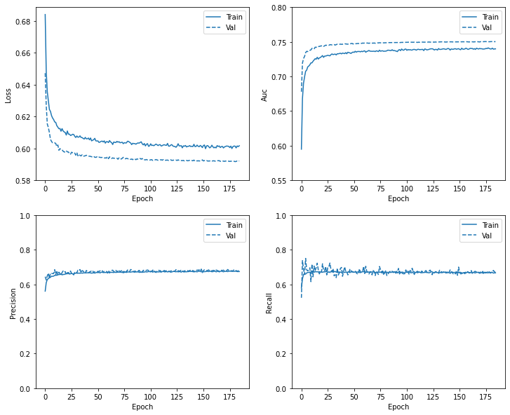

```python
plot_metrics(test_node)
```

```python
train_predictions_test = model.predict(train_features2, batch_size=BATCH_SIZE)
test_predictions_test = model.predict(test_features2, batch_size=BATCH_SIZE)
```

```python
def plot_roc(name, labels, predictions, **kwargs):
  fp, tp, _ = sklearn.metrics.roc_curve(labels, predictions)
  roc_auc = sklearn.metrics.auc(fp, tp)
  plt.plot(100*fp, 100*tp, linewidth=2, **kwargs, label = name)
  plt.title('AUC = %0.2f' % roc_auc)
  plt.xlabel('False positives [%]')
  plt.ylabel('True positives [%]')
  plt.xlim([-0.5,100])
  plt.ylim([0,100.5])
  plt.grid(True)
  ax = plt.gca()
  ax.set_aspect('equal')
```

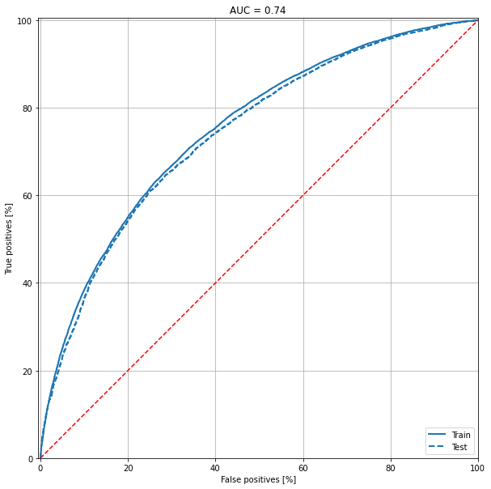

```python
plot_roc("Train", train_labels2, train_predictions_test, color=colors[0])
plot_roc("Test", test_labels2, test_predictions_test, color=colors[0], linestyle='--')
plt.legend(loc='lower right')
plt.plot([0, 100], [0, 100],'r--')
```

The learning process look better based on the Loss history graph. No improvement in ROC-AUC.

### Try more layers

```python
METRICS = [
      keras.metrics.TruePositives(name='tp'),
      keras.metrics.FalsePositives(name='fp'),
      keras.metrics.TrueNegatives(name='tn'),
      keras.metrics.FalseNegatives(name='fn'),
      keras.metrics.BinaryAccuracy(name='accuracy'),
      keras.metrics.Precision(name='precision'),
      keras.metrics.Recall(name='recall'),
      keras.metrics.AUC(name='auc'),
]

# Power scheduling
optimizer = keras.optimizers.SGD(lr=0.01, decay=1e-4)

def make_model(metrics=METRICS, optimizer=optimizer, output_bias=None):
  if output_bias is not None:
    output_bias = tf.keras.initializers.Constant(output_bias)
  model = keras.Sequential([
      keras.layers.Dense(128, activation='relu',
          input_shape=(train_features2.shape[-1],)),
      keras.layers.Dropout(0.5),
      keras.layers.Dense(64, activation='relu'),
      keras.layers.Dropout(0.2),
      keras.layers.Dense(1, activation='sigmoid',
                         bias_initializer=output_bias),
  ])

  model.compile(
      optimizer=optimizer,
      loss=keras.losses.BinaryCrossentropy(),
      metrics=metrics)

  return model
```

```python
EPOCHS = 200
BATCH_SIZE = 25

early_stopping = tf.keras.callbacks.EarlyStopping(
    monitor='val_auc',
    verbose=1,
    patience=10,
    mode='max',
    restore_best_weights=True)
```

```python
model = make_model()
model.summary()
```

```
Model: "sequential_31"
_________________________________________________________________
Layer (type)                 Output Shape              Param #
=================================================================
dense_66 (Dense)             (None, 128)               14336
_________________________________________________________________
dropout_35 (Dropout)         (None, 128)               0
_________________________________________________________________
dense_67 (Dense)             (None, 64)                8256
_________________________________________________________________
dropout_36 (Dropout)         (None, 64)                0
_________________________________________________________________
dense_68 (Dense)             (None, 1)                 65
=================================================================
Total params: 22,657
Trainable params: 22,657
Non-trainable params: 0
_________________________________________________________________
```

```python
model.predict(train_features2[:10])
```

```
array([[0.86265785],
       [0.8749803 ],
       [0.88721347],
       [0.8844779 ],
       [0.8942176 ],
       [0.9184093 ],
       [0.90767974],
       [0.8632645 ],
       [0.8873624 ],
       [0.8932426 ]], dtype=float32)
```

```python
initial_weights = os.path.join(tempfile.mkdtemp(), 'initial_weights')
model.save_weights(initial_weights)
```

```python
model = make_model()
model.load_weights(initial_weights)
test_layer = model.fit(
    train_features2,
    train_labels2,
    batch_size=BATCH_SIZE,
    epochs=EPOCHS,
    callbacks=[early_stopping],
    validation_data=(val_features2, val_labels2))
```

```
Epoch 00087: early stopping
```

```python
def plot_metrics(history):
  metrics = ['loss', 'auc', 'precision', 'recall']
  for n, metric in enumerate(metrics):
    name = metric.replace("_"," ").capitalize()
    plt.subplot(2,2,n+1)
    plt.plot(history.epoch, history.history[metric], color=colors[0], label='Train')
    plt.plot(history.epoch, history.history['val_'+metric],
             color=colors[0], linestyle="--", label='Val')
    plt.xlabel('Epoch')
    plt.ylabel(name)
    if metric == 'loss':
      plt.ylim([0.58, plt.ylim()[1]])
    elif metric == 'auc':
      plt.ylim([0.55,0.8])
    else:
      plt.ylim([0,1])

    plt.legend()
```

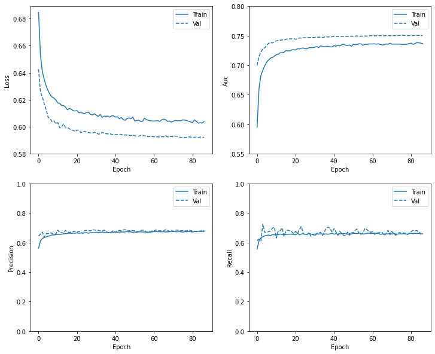

```python
plot_metrics(test_layer)
```

```python
train_predictions_test = model.predict(train_features2, batch_size=BATCH_SIZE)
test_predictions_test = model.predict(test_features2, batch_size=BATCH_SIZE)
```

```python
def plot_roc(name, labels, predictions, **kwargs):
  fp, tp, _ = sklearn.metrics.roc_curve(labels, predictions)
  roc_auc = sklearn.metrics.auc(fp, tp)
  plt.plot(100*fp, 100*tp, linewidth=2, **kwargs, label = name)
  plt.title('AUC = %0.2f' % roc_auc)
  plt.xlabel('False positives [%]')
  plt.ylabel('True positives [%]')
  plt.xlim([-0.5,100])
  plt.ylim([0,100.5])
  plt.grid(True)
  ax = plt.gca()
  ax.set_aspect('equal')
```

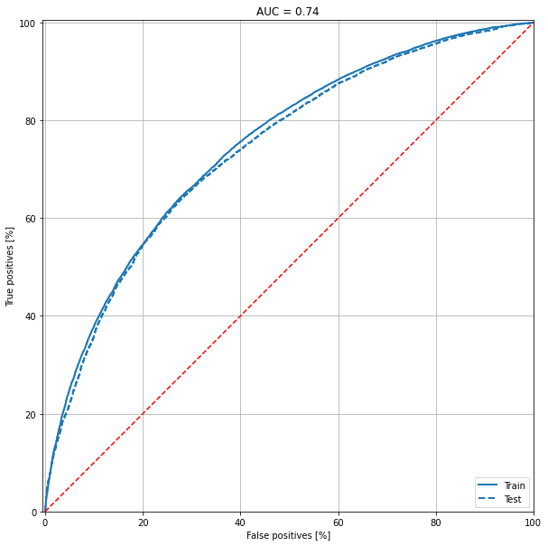

```python
plot_roc("Train", train_labels2, train_predictions_test, color=colors[0])
plot_roc("Test", test_labels2, test_predictions_test, color=colors[0], linestyle='--')
plt.legend(loc='lower right')
plt.plot([0, 100], [0, 100],'r--')
```

Does not improve muc in terms of Loss history graph and ROC-AUC.

### Try a much more complex model

```python
METRICS = [
      keras.metrics.TruePositives(name='tp'),
      keras.metrics.FalsePositives(name='fp'),
      keras.metrics.TrueNegatives(name='tn'),
      keras.metrics.FalseNegatives(name='fn'),
      keras.metrics.BinaryAccuracy(name='accuracy'),
      keras.metrics.Precision(name='precision'),
      keras.metrics.Recall(name='recall'),
      keras.metrics.AUC(name='auc'),
]

# Power scheduling
optimizer = keras.optimizers.SGD(lr=0.01, decay=1e-4)

def make_model(metrics=METRICS, optimizer=optimizer, output_bias=None):
  if output_bias is not None:
    output_bias = tf.keras.initializers.Constant(output_bias)
  model = keras.Sequential([
      keras.layers.Dense(1024, activation='relu',
          input_shape=(train_features2.shape[-1],)),
      keras.layers.Dropout(0.5),
      keras.layers.Dense(512, activation='relu'),
      keras.layers.Dropout(0.2),
      keras.layers.Dense(128, activation='relu'),
      keras.layers.Dropout(0.2),
      keras.layers.Dense(1, activation='sigmoid',
                         bias_initializer=output_bias),
  ])

  model.compile(
      optimizer=optimizer,
      loss=keras.losses.BinaryCrossentropy(),
      metrics=metrics)

  return model
```

```python
EPOCHS = 200
BATCH_SIZE = 25

early_stopping = tf.keras.callbacks.EarlyStopping(
    monitor='val_auc',
    verbose=1,
    patience=10,
    mode='max',
    restore_best_weights=True)
```

```python
model = make_model()
model.summary()
```

```
Model: "sequential_33"
_________________________________________________________________
Layer (type)                 Output Shape              Param #
=================================================================
dense_72 (Dense)             (None, 1024)              114688
_________________________________________________________________
dropout_39 (Dropout)         (None, 1024)              0
_________________________________________________________________
dense_73 (Dense)             (None, 512)               524800
_________________________________________________________________
dropout_40 (Dropout)         (None, 512)               0
_________________________________________________________________
dense_74 (Dense)             (None, 128)               65664
_________________________________________________________________
dropout_41 (Dropout)         (None, 128)               0
_________________________________________________________________
dense_75 (Dense)             (None, 1)                 129
=================================================================
Total params: 705,281
Trainable params: 705,281
Non-trainable params: 0
_________________________________________________________________
```

```python
model.predict(train_features2[:10])
```

```
array([[0.6928829 ],
       [0.6551215 ],
       [0.67916083],
       [0.6634492 ],
       [0.6877329 ],
       [0.6593905 ],
       [0.6954733 ],
       [0.70207745],
       [0.6682209 ],
       [0.66723466]], dtype=float32)
```

```python
initial_weights = os.path.join(tempfile.mkdtemp(), 'initial_weights')
model.save_weights(initial_weights)
```

```python
model = make_model()
model.load_weights(initial_weights)
test_layer2 = model.fit(
    train_features2,
    train_labels2,
    batch_size=BATCH_SIZE,
    epochs=EPOCHS,
    callbacks=[early_stopping],
    validation_data=(val_features2, val_labels2))
```

```
Epoch 00073: early stopping
```

```python
def plot_metrics(history):
  metrics = ['loss', 'auc', 'precision', 'recall']
  for n, metric in enumerate(metrics):
    name = metric.replace("_"," ").capitalize()
    plt.subplot(2,2,n+1)
    plt.plot(history.epoch, history.history[metric], color=colors[0], label='Train')
    plt.plot(history.epoch, history.history['val_'+metric],
             color=colors[0], linestyle="--", label='Val')
    plt.xlabel('Epoch')
    plt.ylabel(name)
    if metric == 'loss':
      plt.ylim([0.58, plt.ylim()[1]])
    elif metric == 'auc':
      plt.ylim([0.55,0.8])
    else:
      plt.ylim([0,1])

    plt.legend()
```

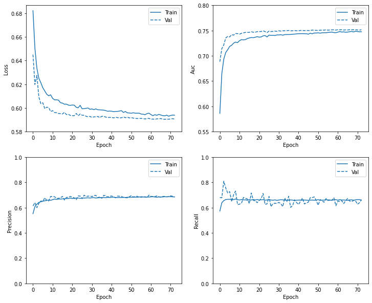

```python
plot_metrics(test_layer2)
```

```python
train_predictions_test = model.predict(train_features2, batch_size=BATCH_SIZE)
test_predictions_test = model.predict(test_features2, batch_size=BATCH_SIZE)
```

```python
def plot_roc(name, labels, predictions, **kwargs):
  fp, tp, _ = sklearn.metrics.roc_curve(labels, predictions)
  roc_auc = sklearn.metrics.auc(fp, tp)
  plt.plot(100*fp, 100*tp, linewidth=2, **kwargs, label = name)
  plt.title('AUC = %0.2f' % roc_auc)
  plt.xlabel('False positives [%]')
  plt.ylabel('True positives [%]')
  plt.xlim([-0.5,100])
  plt.ylim([0,100.5])
  plt.grid(True)
  ax = plt.gca()
  ax.set_aspect('equal')
```

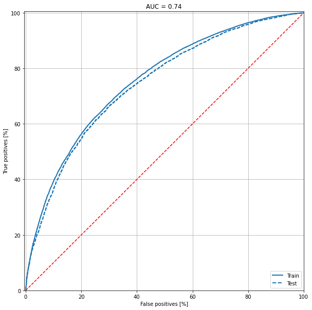

```python
plot_roc("Train", train_labels2, train_predictions_test, color=colors[0])
plot_roc("Test", test_labels2, test_predictions_test, color=colors[0], linestyle='--')
plt.legend(loc='lower right')
plt.plot([0, 100], [0, 100],'r--')
```

The Loss history graph looks better as the gap is smaller. No improvement in ROC-AUC for test dataset. The ROC-AUC for training set looks a little better, which is intuitive given a more complex model.

### Try another complex model

```python
METRICS = [
      keras.metrics.TruePositives(name='tp'),
      keras.metrics.FalsePositives(name='fp'),
      keras.metrics.TrueNegatives(name='tn'),
      keras.metrics.FalseNegatives(name='fn'),
      keras.metrics.BinaryAccuracy(name='accuracy'),
      keras.metrics.Precision(name='precision'),
      keras.metrics.Recall(name='recall'),
      keras.metrics.AUC(name='auc'),
]

# Power scheduling
optimizer = keras.optimizers.SGD(lr=0.01, decay=1e-4)

def make_model(metrics=METRICS, optimizer=optimizer, output_bias=None):
  if output_bias is not None:
    output_bias = tf.keras.initializers.Constant(output_bias)
  model = keras.Sequential([
      keras.layers.Dense(2048, activation='relu',
          input_shape=(train_features2.shape[-1],)),
      keras.layers.Dropout(0.5),
      keras.layers.Dense(1024, activation='relu'),
      keras.layers.Dropout(0.3),
      keras.layers.Dense(1024, activation='relu'),
      keras.layers.Dropout(0.2),
      keras.layers.Dense(1, activation='sigmoid',
                         bias_initializer=output_bias),
  ])

  model.compile(
      optimizer=optimizer,
      loss=keras.losses.BinaryCrossentropy(),
      metrics=metrics)

  return model
```

```python
EPOCHS = 200
BATCH_SIZE = 25

early_stopping = tf.keras.callbacks.EarlyStopping(
    monitor='val_auc',
    verbose=1,
    patience=10,
    mode='max',
    restore_best_weights=True)
```

```python
model = make_model()
model.summary()
```

```
Model: "sequential"
_________________________________________________________________
Layer (type)                 Output Shape              Param #
=================================================================
dense (Dense)                (None, 2048)              229376
_________________________________________________________________
dropout (Dropout)            (None, 2048)              0
_________________________________________________________________
dense_1 (Dense)              (None, 1024)              2098176
_________________________________________________________________
dropout_1 (Dropout)          (None, 1024)              0
_________________________________________________________________
dense_2 (Dense)              (None, 1024)              1049600
_________________________________________________________________
dropout_2 (Dropout)          (None, 1024)              0
_________________________________________________________________
dense_3 (Dense)              (None, 1)                 1025
=================================================================
Total params: 3,378,177
Trainable params: 3,378,177
Non-trainable params: 0
_________________________________________________________________
```

```python
model.predict(train_features2[:10])
```

```
array([[0.8637062 ],
       [0.8576397 ],
       [0.8737439 ],
       [0.87306017],
       [0.86032736],
       [0.85795784],
       [0.8619231 ],
       [0.85780334],
       [0.8729255 ],
       [0.86010295]], dtype=float32)
```

```python
initial_weights = os.path.join(tempfile.mkdtemp(), 'initial_weights')
model.save_weights(initial_weights)
```

```python
model = make_model()
model.load_weights(initial_weights)
test_layer3 = model.fit(
    train_features2,
    train_labels2,
    batch_size=BATCH_SIZE,
    epochs=EPOCHS,
    callbacks=[early_stopping],
    validation_data=(val_features2, val_labels2))
```

```
Epoch 00061: early stopping
```

```python
def plot_metrics(history):
  metrics = ['loss', 'auc', 'precision', 'recall']
  for n, metric in enumerate(metrics):
    name = metric.replace("_"," ").capitalize()
    plt.subplot(2,2,n+1)
    plt.plot(history.epoch, history.history[metric], color=colors[0], label='Train')
    plt.plot(history.epoch, history.history['val_'+metric],
             color=colors[0], linestyle="--", label='Val')
    plt.xlabel('Epoch')
    plt.ylabel(name)
    if metric == 'loss':
      plt.ylim([0.58, plt.ylim()[1]])
    elif metric == 'auc':
      plt.ylim([0.55,0.8])
    else:
      plt.ylim([0,1])

    plt.legend()
```

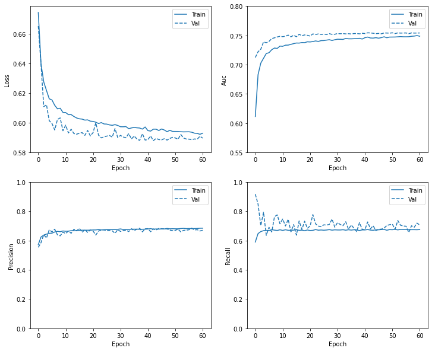

```python
plot_metrics(test_layer3)
```

```python
train_predictions_test = model.predict(train_features2, batch_size=BATCH_SIZE)
test_predictions_test = model.predict(test_features2, batch_size=BATCH_SIZE)
```

```python
def plot_roc(name, labels, predictions, **kwargs):
  fp, tp, _ = sklearn.metrics.roc_curve(labels, predictions)
  roc_auc = sklearn.metrics.auc(fp, tp)
  plt.plot(100*fp, 100*tp, linewidth=2, **kwargs, label = name)
  plt.title('AUC = %0.2f' % roc_auc)
  plt.xlabel('False positives [%]')
  plt.ylabel('True positives [%]')
  plt.xlim([-0.5,100])
  plt.ylim([0,100.5])
  plt.grid(True)
  ax = plt.gca()
  ax.set_aspect('equal')
```

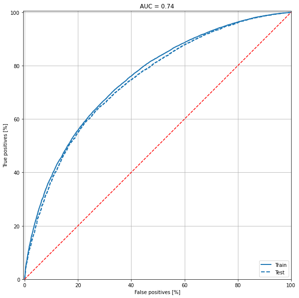

```python
plot_roc("Train", train_labels2, train_predictions_test, color=colors[0])
plot_roc("Test", test_labels2, test_predictions_test, color=colors[0], linestyle='--')
plt.legend(loc='lower right')
plt.plot([0, 100], [0, 100],'r--')
```

The Loss history graph converged but showing much more noise in the validation curve. Not much change in ROC curve. Increased noise in recall history graph (validation curve).

### See whether more complicated model would have better performance

```python
METRICS = [
      keras.metrics.TruePositives(name='tp'),
      keras.metrics.FalsePositives(name='fp'),
      keras.metrics.TrueNegatives(name='tn'),
      keras.metrics.FalseNegatives(name='fn'),
      keras.metrics.BinaryAccuracy(name='accuracy'),
      keras.metrics.Precision(name='precision'),
      keras.metrics.Recall(name='recall'),
      keras.metrics.AUC(name='auc'),
]

# Power scheduling
optimizer = keras.optimizers.SGD(lr=0.01, decay=1e-4)

def make_model(metrics=METRICS, optimizer=optimizer, output_bias=None):
  if output_bias is not None:
    output_bias = tf.keras.initializers.Constant(output_bias)
  model = keras.Sequential([
      keras.layers.Dense(2048, activation='relu',
          input_shape=(train_features2.shape[-1],)),
      keras.layers.Dropout(0.5),
      keras.layers.Dense(2048, activation='relu'),
      keras.layers.Dropout(0.3),
      keras.layers.Dense(1024, activation='relu'),
      keras.layers.Dropout(0.2),
      keras.layers.Dense(1, activation='sigmoid',
                         bias_initializer=output_bias),
  ])

  model.compile(
      optimizer=optimizer,
      loss=keras.losses.BinaryCrossentropy(),
      metrics=metrics)

  return model
```

```python
EPOCHS = 200
BATCH_SIZE = 25

early_stopping = tf.keras.callbacks.EarlyStopping(
    monitor='val_auc',
    verbose=1,
    patience=10,
    mode='max',
    restore_best_weights=True)
```

```python
model = make_model()
model.summary()
```

```
Model: "sequential_37"
_________________________________________________________________
Layer (type)                 Output Shape              Param #
=================================================================
dense_88 (Dense)             (None, 2048)              229376
_________________________________________________________________
dropout_51 (Dropout)         (None, 2048)              0
_________________________________________________________________
dense_89 (Dense)             (None, 2048)              4196352
_________________________________________________________________
dropout_52 (Dropout)         (None, 2048)              0
_________________________________________________________________
dense_90 (Dense)             (None, 1024)              2098176
_________________________________________________________________
dropout_53 (Dropout)         (None, 1024)              0
_________________________________________________________________
dense_91 (Dense)             (None, 1)                 1025
=================================================================
Total params: 6,524,929
Trainable params: 6,524,929
Non-trainable params: 0
_________________________________________________________________
```

```python
model.predict(train_features2[:10])
```

```
array([[0.7787437 ],
       [0.829008  ],
       [0.7938749 ],
       [0.7805618 ],
       [0.790692  ],
       [0.80218047],
       [0.7816584 ],
       [0.78100145],
       [0.8211592 ],
       [0.787204  ]], dtype=float32)
```

```python
initial_weights = os.path.join(tempfile.mkdtemp(), 'initial_weights')
model.save_weights(initial_weights)
```

```python
model = make_model()
model.load_weights(initial_weights)
test_layer4 = model.fit(
    train_features2,
    train_labels2,
    batch_size=BATCH_SIZE,
    epochs=EPOCHS,
    callbacks=[early_stopping],
    validation_data=(val_features2, val_labels2))
```

```
Epoch 00073: early stopping
```

```python
def plot_metrics(history):
  metrics = ['loss', 'auc', 'precision', 'recall']
  for n, metric in enumerate(metrics):
    name = metric.replace("_"," ").capitalize()
    plt.subplot(2,2,n+1)
    plt.plot(history.epoch, history.history[metric], color=colors[0], label='Train')
    plt.plot(history.epoch, history.history['val_'+metric],
             color=colors[0], linestyle="--", label='Val')
    plt.xlabel('Epoch')
    plt.ylabel(name)
    if metric == 'loss':
      plt.ylim([0.58, plt.ylim()[1]])
    elif metric == 'auc':
      plt.ylim([0.55,0.8])
    else:
      plt.ylim([0,1])

    plt.legend()
```

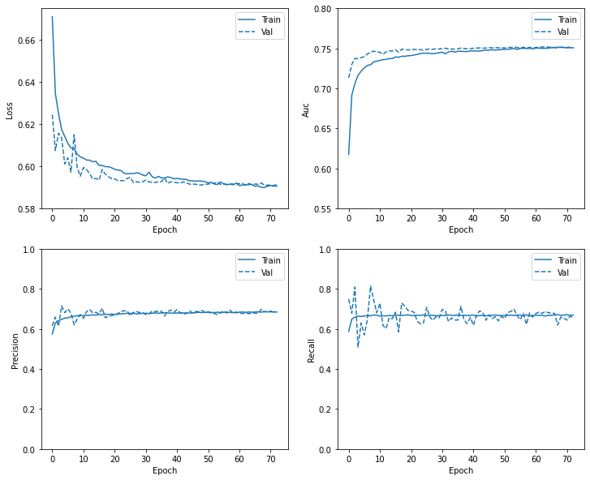

```python
plot_metrics(test_layer4)
```

```python
train_predictions_test = model.predict(train_features2, batch_size=BATCH_SIZE)
test_predictions_test = model.predict(test_features2, batch_size=BATCH_SIZE)
```

```python
def plot_roc(name, labels, predictions, **kwargs):
  fp, tp, _ = sklearn.metrics.roc_curve(labels, predictions)
  roc_auc = sklearn.metrics.auc(fp, tp)
  plt.plot(100*fp, 100*tp, linewidth=2, **kwargs, label = name)
  plt.title('AUC = %0.2f' % roc_auc)
  plt.xlabel('False positives [%]')
  plt.ylabel('True positives [%]')
  plt.xlim([-0.5,100])
  plt.ylim([0,100.5])
  plt.grid(True)
  ax = plt.gca()
  ax.set_aspect('equal')
```

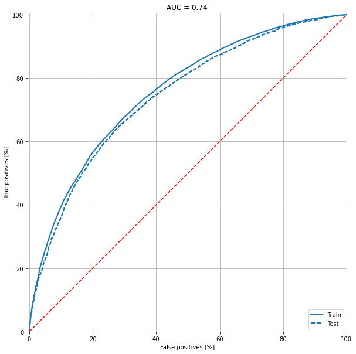

```python
plot_roc("Train", train_labels2, train_predictions_test, color=colors[0])
plot_roc("Test", test_labels2, test_predictions_test, color=colors[0], linestyle='--')
plt.legend(loc='lower right')
plt.plot([0, 100], [0, 100],'r--')
```

Not much improvement.

Considering the tradeoff between loss history graph and recall history graph, the model with three layers (2048 nodes 0.5 dropout, 1024 nodes 0.3 dropout, 1024 nodes 0.2 dropout) was the best model possible for HIV testing.